# assignment-3

#### 11/10/2020

## COMP 541 - Assignment 3 - Team 6

### Table of Contents:

- 1. Preparing the Data
- 1.1. Importing Libraries
- 1.2. Combining the Source Tables
- 1.3. Transforming Features to their Correct Types
- 2. Data Exploration
- 2.1. Exploring Continuous Features
- 2.1.1. Feature Overview
- 2.1.1.1. Budget
- 2.1.1.2. Gross
- 2.1.1.3. Profitability Ratio
- 2.1.2. Correlation & Covariance Matrix
- 2.2. Exploring Categorical Features
- 2.2.1. Class Distributions & Imbalance
- 2.2.1.1. Genre
- 2.2.1.2. Company
- 2.2.1.3. Country
- 2.2.1.4. Director
- 2.2.1.5. Rating
- 2.2.1.6. Year Released
- 2.2.1.7. Isprofit
- 2.2.2. Categorical Feature Dependency Using Chi-Square Test
- 2.2.2.1. Chi-square Test for Each Feature
- 2.2.2.2. Chi-square Test - Summary
- 3. Frequent Pattern Analysis
- 3.1. Genres (Genre List)
- 3.2. Spoken Languages
- 3.3. Keywords
- 3.4. Overview
- 4. Results
- 4.1. Data Exploration Results - Continuous Features
- 4.2. Data Exploration Results - Categorical Features
- 4.3. Frequent Pattern Analysis Results

# 1. Preparing the Data

## 1.1. Importing Libraries

```python
import pandas as pd
import numpy as np
import datetime
import os
import matplotlib.pyplot as plt
import seaborn as sns
import itertools as it
import scipy.stats as sp
from scipy.stats import chi2_contingency
from scipy.stats import chi2
from mlxtend.preprocessing import TransactionEncoder
from mlxtend.frequent_patterns import apriori, association_rules
```

## 1.2. Combining the Source Tables

```python
print('> Reading raw data:')
movies = pd.read_csv('./data/movies.csv')
metadata = pd.read_csv('./data/metadata.csv')
keywords = pd.read_csv('./data/keywords.csv')
print("metadata; records: "+str(metadata.shape[0])+", fields: "+str(metadata.shape[1]))
print("keywords; records: "+str(keywords.shape[0])+", fields: "+str(keywords.shape[1]))
print("movies; records: "+str(movies.shape[0])+", fields: "+str(movies.shape[1]))

print("")
print('> Removing duplicate rows from each table:')
movies.drop_duplicates(subset='name',keep=False,inplace=True)
metadata.drop_duplicates(subset='title',keep=False,inplace=True)
keywords.drop_duplicates(subset='id',keep=False,inplace=True)
print('> After the removal, we end up with the following number of rows for each table:')
print("metadata; records: "+str(metadata.shape[0])+", fields: "+str(metadata.shape[1]))
print("keywords; records: "+str(keywords.shape[0])+", fields: "+str(keywords.shape[1]))
print("movies; records: "+str(movies.shape[0])+", fields: "+str(movies.shape[1]))

print("")
print('> Combining metadata and keywords tables using "id" column that is common in both tables.')
metadata['id'] = metadata['id'].apply(lambda x: int(x))
metadata_keywords = metadata.merge(keywords,how='inner')
print('metadata + keywords --> shape: '+str(metadata_keywords.shape[0])+", fields: "+str(metadata_keywords.shape[1]))

print("")
print('> Combining movies and previously combined metadata+keywords table using movie titles')
df = movies.merge(metadata_keywords,how='inner',left_on='name',right_on='original_title')
print('df = movies + metadata + keywords --> shape: '+str(df.shape[0])+", fields: "+str(df.shape[1]))
```

```
> Reading raw data:
metadata; records: 45466, fields: 11
keywords; records: 46419, fields: 2
movies; records: 4638, fields: 18

> Removing duplicate rows from each table:
> After the removal, we end up with the following number of rows for each table:
metadata; records: 39943, fields: 11
keywords; records: 44447, fields: 2
movies; records: 4570, fields: 18

> Combining metadata and keywords tables using "id" column that is common in both tables.
metadata + keywords --> shape: 39089, fields: 12

> Combining movies and previously combined metadata+keywords table using movie titles
df = movies + metadata + keywords --> shape: 3524, fields: 30
```

###### The last table, "df" is the combined data from three sources and thus will be used in throughout the project. We will still manipulate the data in terms of preprocessing and feature engineering, but we do not expect any further reduction in number of rows. Still, it can happen due to corrupt data issues.

## 1.3. Transforming Features to their Correct Types

By observing the data, we see that following columns need not any initial transformation:

- genre
- company
- budget
- country
- director
- overview
- tagline

And the following features had to change due to:

- released: this is a date column with dd.mm.yyyy format. For the sake of simplicity, we are only interested in the year the movies are released. Therefore we apply a transformation to extract year information from this column and write it to *year_released* column.

Of course, all of the categorical features will be converted to continuous (or, at least discrete) fields before modeling stage, but for now, we are just interested in the integrity of the data.

```python
df['year_released'] = df.released.apply(lambda x: x[:-6][-4:])
df[df.year_released.isin(['','1','2'])] = 0
df['year_released'] = df.year_released.astype(int)
df.year_released.replace(0,int(df.year_released.mean()), inplace=True)

popular_companies = df.company.value_counts().index.tolist()[:20]
popular_directors = df.director.value_counts().index.tolist()[:20]

df['country'] = df.country.apply(lambda x: x if x=='USA' else 'Other')
df['company'] = df.company.apply(lambda x: 'Other' if x not in popular_companies else x)
df['director'] = df.director.apply(lambda x: 'Other' if x not in popular_directors else x)
```

```python
df.to_csv('data/raw_training_data.csv')
```

# 2. Data Exploration

```python
df = pd.DataFrame(pd.read_csv('data/raw_training_data.csv'))
```

## 2.1. Exploring Continuous Features

Our data has the following columns that we can use to conduct the statistical description:

- Budget
- Gross
- Profitability ratio

### 2.1.1. Feature Overview

#### 2.1.1.1. Budget

```python
sm = pd.DataFrame(
    [
        ['count',df['budget'].count()],
        ['min',df.budget.min()],
        ['max',df.budget.max()],
        ['mean',df.budget.mean()],
        ['median',df.budget.median()],
        ['std.dev',df.budget.std()],
        ['variance',df.budget.var()],
        ['Q1',df.budget.quantile(0.25)],
        ['Q3',df.budget.quantile(0.75)],
        ['IQR',df.budget.quantile(0.75)-df.budget.quantile(0.25)]
    ],
    columns=['property','value']
)
sm['value'] = sm.value.astype(int)
sm
```

|  | property | value |
| --- | --- | --- |
| 0 | count | 3524 |
| 1 | min | 0 |
| 2 | max | 300000000 |
| 3 | mean | 36468367 |
| 4 | median | 23000000 |
| 5 | std.dev | 40633689 |
| 6 | variance | 1651096751521254 |
| 7 | Q1 | 10000000 |
| 8 | Q3 | 48000000 |
| 9 | IQR | 38000000 |

Figure 1: Data summary based on statistical description of budget

The Figure 1 represents the data summary based on statistical description of the feature budget. There are measures of central tendency (mean, median), dispersion (quartiles, variance, standard deviation, interquartile range), and some other statistical descriptions, like minimum, maximum and count. The count() function returns the number of cells for each row or column. The budget column has 3524 non-empty cells. The minimum value of the budget is 0, while the maximum - 300,000,000.

#### Boxplot of the *budget*

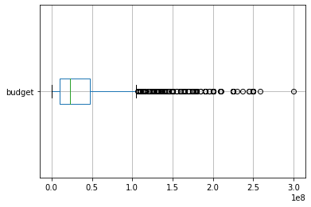

```python
df[['budget']].boxplot(vert=False)
plt.show()
```

Figure 2: Boxplot of feature budget

The Figure 2 shows the boxplot of the feature budget. The graph represents five number summary: “minimum, first quartile, median, third quartile, and ''maximum”. The ends of the box are the quartiles, Q1 and Q3, while the box length is interquartile range (IQR). While from the graph, we can get an approximate value of Q1 and Q3, it can be seen that the exact value of Q1 is 10,000,000 and Q3 is 48,000,000 from Figure 1. The median is marked as the line within the box, which is equal to 23,000,000. Two lines (called whiskers) outside the box extend to the smallest (Minimum) and largest (Maximum) observations. The circles are the outliers.

#### Skewness of the *budget*

```
skewness
budget    2.253961
dtype: float64
```

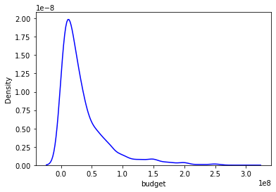

```python
sns.kdeplot(df['budget'], color='b')
print('skewness')
print(df[['budget']].skew())
```

Figure 3: Skewness of budget

The Figure 3 demonstrates that the budget’s distribution is asymmetrical, because the tail is skewed to the right. As the tail is longer towards the right-hand side, the value of skewness is positive. The value of the skewness is 2.253961, which means that the distribution is highly skewed.

#### 2.1.1.2. Gross

```python
sm = pd.DataFrame(
    [
        ['count',df['gross'].count()],
        ['min',df.gross.min()],
        ['max',df.gross.max()],
        ['mean',df.gross.mean()],
        ['median',df.gross.median()],
        ['std.dev',df.gross.std()],
        ['variance',df.gross.var()],
        ['Q1',df.gross.quantile(0.25)],
        ['Q3',df.gross.quantile(0.75)],
        ['IQR',df.gross.quantile(0.75)-df.gross.quantile(0.25)]
    ],
    columns=['property','value']
)
sm['value'] = sm.value.astype(int)
sm
```

|  | property | value |
| --- | --- | --- |
| 0 | count | 3524 |
| 1 | min | 0 |
| 2 | max | 936662225 |
| 3 | mean | 47725202 |
| 4 | median | 25111099 |
| 5 | std.dev | 67071214 |
| 6 | variance | 4498547873591042 |
| 7 | Q1 | 6955428 |
| 8 | Q3 | 60366724 |
| 9 | IQR | 53411296 |

Figure 4: Data summary based on statistical description of gross

#### Boxplot of the *gross*

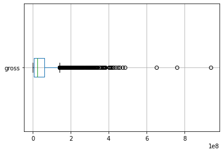

```python
df[['gross']].boxplot(vert=False)
plt.show()
```

Figure 5: Boxplot of feature gross

The Figure 5 shows the boxplot of the feature gross. The graph represents five number summary: “minimum, first quartile, median, third quartile, and ''maximum”. The ends of the box are the quartiles, Q1 and Q3, while the box length is interquartile range (IQR). While from the graph, we can get an approximate value of Q1 and Q3, it can be seen that the exact value of Q1 is 6,955,428 and Q3 is 60,366,724 from Figure 4. The median is marked as the line within the box, which is equal to 25,111,099. Two lines (called whiskers) outside the box extend to the smallest (Minimum) and largest (Maximum) observations. The circles are the outliers.

#### Skewness of the *gross*

```
skewness
gross    3.49795
dtype: float64
```

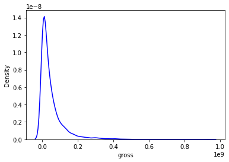

```python
sns.kdeplot(df['gross'], color='b')
print('skewness')
print(df[['gross']].skew())
```

Figure 6: Skewness of gross

The Figure 6 demonstrates that the grosst’s distribution is asymmetrical, because the tail is skewed to the right. As the tail is longer towards the right-hand side, the value of skewness is positive. The value of the skewness is 3.49795, which means that the distribution is highly skewed.

#### 2.1.1.3. Profitability ratio

```python
sm = pd.DataFrame(
    [
        ['count',df['profitability_ratio'].count()],
        ['min',df.profitability_ratio.min()],
        ['max',df.profitability_ratio.max()],
        ['mean',df.profitability_ratio.mean()],
        ['median',df.profitability_ratio.median()],
        ['std.dev',df.profitability_ratio.std()],
        ['variance',df.profitability_ratio.var()],
        ['Q1',df.profitability_ratio.quantile(0.25)],
        ['Q3',df.profitability_ratio.quantile(0.75)],
        ['IQR',df.profitability_ratio.quantile(0.75)-df.profitability_ratio.quantile(0.25)]
    ],
    columns=['property','value']
)
sm['value'] = sm.value.astype(float)
sm
```

|  | property | value |
| --- | --- | --- |
| 0 | count | 3524.000000 |
| 1 | min | -0.999979 |
| 2 | max | 7193.587333 |
| 3 | mean | 3.996876 |
| 4 | median | 0.020240 |
| 5 | std.dev | 127.868810 |
| 6 | variance | 16350.432647 |
| 7 | Q1 | -0.552571 |
| 8 | Q3 | 1.029155 |
| 9 | IQR | 1.581726 |

Figure 7: Data summary based on statistical description of profitability ratio

The Figure 7 represents the data summary based on statistical description of the feature profitability ratio. There are measures of central tendency (mean, median), dispersion (quartiles, variance, standard deviation, interquartile range), and some other statistical descriptions, like minimum, maximum and count. The profitability ratio column has 3524 non-empty cells. The minimum value of the budget is -0.999979, while the maximum - 7,193.587333.

#### Boxplot of the *profitability ratio*

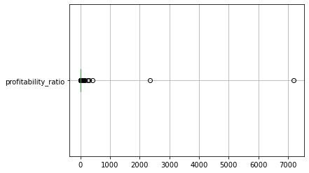

```python
df[['profitability_ratio']].boxplot(vert=False)
plt.show()
```

Figure 8: Boxplot of feature profitability ratio

The Figure 8 shows the boxplot of the feature profitability ratio. The graph represents five number summary: “minimum, first quartile, median, third quartile, and ''maximum”. The ends of the box are the quartiles, Q1 and Q3, while the box length is interquartile range (IQR). While from the graph, we can get an approximate value of Q1 and Q3, it can be seen that the exact value of Q1 is -0.552571 and Q3 is 1.029155 from Figure 7. The median is marked as the line within the box, which is equal to 0.02024. Two lines (called whiskers) outside the box extend to the smallest (Minimum) and largest (Maximum) observations. The circles are the outliers.

#### Skewness of the *profitability ratio*

```
skewness
profitability_ratio    52.233907
dtype: float64
```

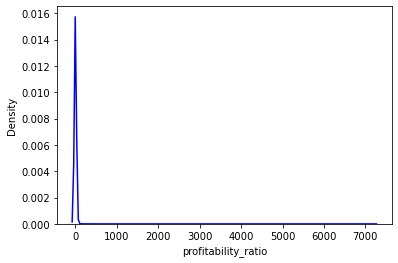

```python
sns.kdeplot(df['profitability_ratio'], color='b')
print('skewness')
print(df[['profitability_ratio']].skew())
```

Figure 9: Skewness of profitability ratio

The Figure 9 demonstrates that the profitability ratio’s distribution is asymmetrical, because the tail is skewed to the right. As the tail is longer towards the right-hand side, the value of skewness is positive. The value of the skewness is 52.233907, which means that the distribution is highly skewed.

### 2.1.2. Correlation & Covariance Matrix

```python
corr_df = df[['budget','gross','profitability_ratio']].corr()
```

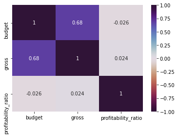

```python
sns.heatmap(corr_df, vmin=-1, vmax=1, cmap='twilight_shifted_r', annot=True);
```

```python
cov_df = df[['budget','gross','profitability_ratio']].cov()
cov_df
```

|  | budget | gross | profitability_ratio |
| --- | --- | --- | --- |
| budget | 1.651097e+15 | 1.861042e+15 | -1.345409e+08 |
| gross | 1.861042e+15 | 4.498548e+15 | 2.081329e+08 |
| profitability_ratio | -1.345409e+08 | 2.081329e+08 | 1.635043e+04 |

## 2.2. Exploring Categorical Features

### 2.2.1. Class Distributions & Imbalance

#### 2.2.1.1. Genres

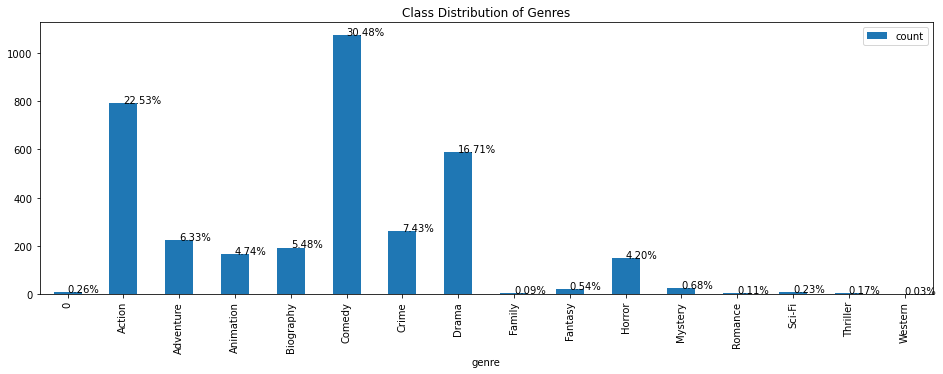

```python
class_counts = pd.DataFrame(df.groupby('genre').size(),columns=['count']).reset_index()
class_counts['percentage']=class_counts['count']/class_counts['count'].sum()*100
ax = class_counts.plot(x='genre',y='count',kind='bar',title='Class Distribution of Genres',figsize=(16,5));
[ax.text(i, class_counts.loc[i]['count'],
         '{:.2f}%'.format(class_counts.loc[i].percentage)) for i in class_counts.index];
```

```python
for i in class_counts.index:
    if (class_counts.loc[i].percentage/100)>=0.25:
        print(class_counts.loc[i]['genre'] + " is balanced")
    elif (class_counts.loc[i].percentage/100)>=0.1:
        print(class_counts.loc[i]['genre'] + " is Slightly Imbalanced")
    else:
        print(class_counts.loc[i]['genre'] + " is Severely Imbalanced")
```

```
0 is Severely Imbalanced
Action is Slightly Imbalanced
Adventure is Severely Imbalanced
Animation is Severely Imbalanced
Biography is Severely Imbalanced
Comedy is balanced
Crime is Severely Imbalanced
Drama is Slightly Imbalanced
Family is Severely Imbalanced
Fantasy is Severely Imbalanced
Horror is Severely Imbalanced
Mystery is Severely Imbalanced
Romance is Severely Imbalanced
Sci-Fi is Severely Imbalanced
Thriller is Severely Imbalanced
Western is Severely Imbalanced
```

#### 2.2.1.2. Company

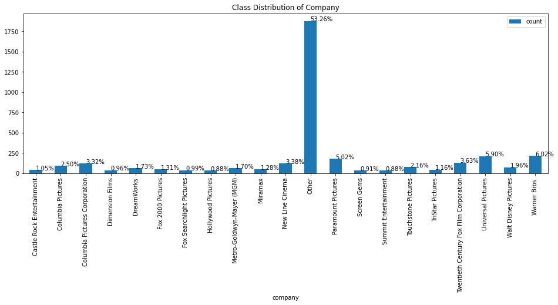

```python
class_counts = pd.DataFrame(df.groupby('company').size(),columns=['count']).reset_index()
#class_counts = class_counts[class_counts['count']>=10].reset_index()
class_counts['percentage']=class_counts['count']/class_counts['count'].sum()*100
ax = class_counts.plot(x='company',y='count',kind='bar',title='Class Distribution of Company',figsize=(16,5));
[ax.text(i, class_counts.loc[i]['count'],
         '{:.2f}%'.format(class_counts.loc[i].percentage)) for i in class_counts.index];
```

```python
for i in class_counts.index:
    if (class_counts.loc[i].percentage/100)>=0.25:
        print(class_counts.loc[i]['company'] + " is balanced")
    elif (class_counts.loc[i].percentage/100)>=0.1:
        print(class_counts.loc[i]['company'] + " is Slightly Imbalance")
    else:
        print(class_counts.loc[i]['company'] + " is Severely Imbalance")
```

```
Castle Rock Entertainment is Severely Imbalance
Columbia Pictures is Severely Imbalance
Columbia Pictures Corporation is Severely Imbalance
Dimension Films is Severely Imbalance
DreamWorks is Severely Imbalance
Fox 2000 Pictures is Severely Imbalance
Fox Searchlight Pictures is Severely Imbalance
Hollywood Pictures is Severely Imbalance
Metro-Goldwyn-Mayer (MGM) is Severely Imbalance
Miramax is Severely Imbalance
New Line Cinema is Severely Imbalance
Other is balanced
Paramount Pictures is Severely Imbalance
Screen Gems is Severely Imbalance
Summit Entertainment is Severely Imbalance
Touchstone Pictures is Severely Imbalance
TriStar Pictures is Severely Imbalance
Twentieth Century Fox Film Corporation is Severely Imbalance
Universal Pictures is Severely Imbalance
Walt Disney Pictures is Severely Imbalance
Warner Bros. is Severely Imbalance
```

#### 2.2.1.3. Country

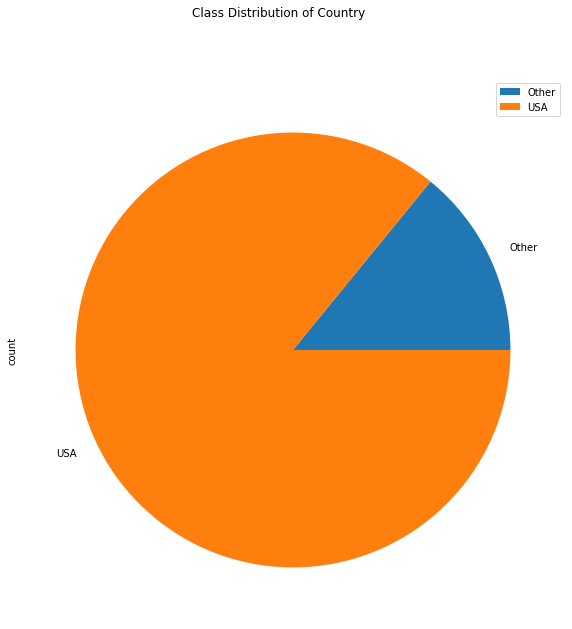

```python
class_counts = pd.DataFrame(df.groupby('country').size(),columns=['count']).reset_index()
#class_counts = class_counts[class_counts['count']>=10].reset_index()
class_counts['percentage']=class_counts['count']/class_counts['count'].sum()*100
ax = class_counts.plot(x='country',y='count',kind='pie',title='Class Distribution of Country',figsize=(16,10),
                       subplots=True, labels=class_counts.country);
#[ax.text(i, class_counts.loc[i]['count'],'{:.2f}%'.format(class_counts.loc[i].percentage))
#for i in class_counts.index];
```

```python
for i in class_counts.index:
    if (class_counts.loc[i].percentage/100)>=0.25:
        print(class_counts.loc[i]['country'] + " is balanced")
    elif (class_counts.loc[i].percentage/100)>=0.1:
        print(class_counts.loc[i]['country'] + " is Slightly Imbalance")
    else:
        print(class_counts.loc[i]['country'] + " is Severely Imbalance")
```

```
Other is Slightly Imbalance
USA is balanced
```

#### 2.2.1.4. Director

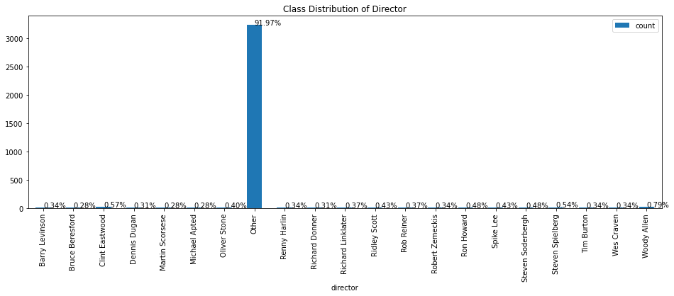

```python
class_counts = pd.DataFrame(df.groupby('director').size(),columns=['count']).reset_index()
#class_counts = class_counts[class_counts['count']>=10].reset_index()
class_counts['percentage']=class_counts['count']/class_counts['count'].sum()*100
ax = class_counts.plot(x='director',y='count',kind='bar',title='Class Distribution of Director',figsize=(16,5));
[ax.text(i, class_counts.loc[i]['count'],
         '{:.2f}%'.format(class_counts.loc[i].percentage)) for i in class_counts.index];
```

```python
for i in class_counts.index:
    if (class_counts.loc[i].percentage/100)>=0.25:
        print(class_counts.loc[i]['director'] + " is balanced")
    elif (class_counts.loc[i].percentage/100)>=0.1:
        print(class_counts.loc[i]['director'] + " is Slightly Imbalance")
    else:
        print(class_counts.loc[i]['director'] + " is Severely Imbalance")
```

```
Barry Levinson is Severely Imbalance
Bruce Beresford is Severely Imbalance
Clint Eastwood is Severely Imbalance
Dennis Dugan is Severely Imbalance
Martin Scorsese is Severely Imbalance
Michael Apted is Severely Imbalance
Oliver Stone is Severely Imbalance
Other is balanced
Renny Harlin is Severely Imbalance
Richard Donner is Severely Imbalance
Richard Linklater is Severely Imbalance
Ridley Scott is Severely Imbalance
Rob Reiner is Severely Imbalance
Robert Zemeckis is Severely Imbalance
Ron Howard is Severely Imbalance
Spike Lee is Severely Imbalance
Steven Soderbergh is Severely Imbalance
Steven Spielberg is Severely Imbalance
Tim Burton is Severely Imbalance
Wes Craven is Severely Imbalance
Woody Allen is Severely Imbalance
```

#### 2.2.1.5. Rating

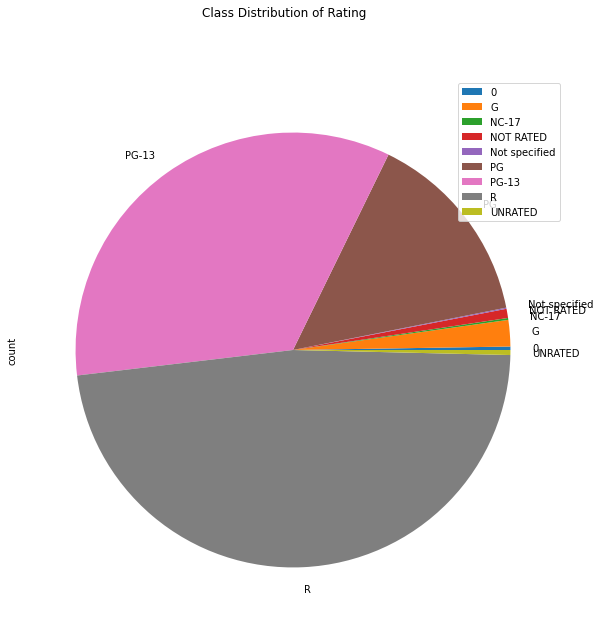

```python
class_counts = pd.DataFrame(df.groupby('rating').size(),columns=['count']).reset_index()
#class_counts = class_counts[class_counts['count']>=10].reset_index()
class_counts['percentage']=class_counts['count']/class_counts['count'].sum()*100
#ax = class_counts.plot(x='rating',y='count',kind='bar',title='Class Distribution of Genres',figsize=(16,5));
#[ax.text(i, class_counts.loc[i]['count'],
#         '{:.2f}%'.format(class_counts.loc[i].percentage)) for i in class_counts.index];
ax = class_counts.plot(x='rating',y='count',kind='pie',title='Class Distribution of Rating',
                       figsize=(10,10),subplots=True, labels=class_counts.rating);
```

```python
for i in class_counts.index:
    if (class_counts.loc[i].percentage/100)>=0.25:
        print(class_counts.loc[i]['rating'] + " is balanced")
    elif (class_counts.loc[i].percentage/100)>=0.1:
        print(class_counts.loc[i]['rating'] + " is Slightly Imbalance")
    else:
        print(class_counts.loc[i]['rating'] + " is Severely Imbalance")
```

```
0 is Severely Imbalance
G is Severely Imbalance
NC-17 is Severely Imbalance
NOT RATED is Severely Imbalance
Not specified is Severely Imbalance
PG is Slightly Imbalance
PG-13 is balanced
R is balanced
UNRATED is Severely Imbalance
```

#### 2.2.1.6. Year Released

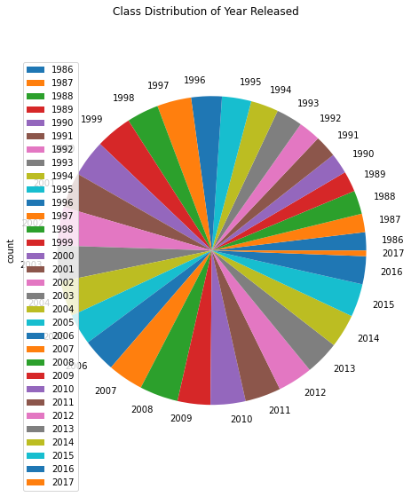

```python
class_counts = pd.DataFrame(df.groupby('year_released').size(),columns=['count']).reset_index()
#class_counts = class_counts[class_counts['count']>=10].reset_index()
class_counts['percentage']=class_counts['count']/class_counts['count'].sum()*100
#ax = class_counts.plot(x='year_released',y='count',kind='bar',title='Class Distribution of Genres',figsize=(16,5));
#[ax.text(i, class_counts.loc[i]['count'],
#         '{:.2f}%'.format(class_counts.loc[i].percentage)) for i in class_counts.index];
ax = class_counts.plot(x='year_released',y='count',kind='pie',title='Class Distribution of Year Released',
                       figsize=(8,8),subplots=True, labels=class_counts.year_released);
```

```python
for i in class_counts.index:
    if (class_counts.loc[i].percentage/100)>=0.25:
        print(str(class_counts.loc[i]['year_released']) + " is balanced")
    elif (class_counts.loc[i].percentage/100)>=0.1:
        print(str(class_counts.loc[i]['year_released']) + " is Slightly Imbalance")
    else:
        print(str(class_counts.loc[i]['year_released']) + " is Severely Imbalance")
```

```
1986.0 is Severely Imbalance
1987.0 is Severely Imbalance
1988.0 is Severely Imbalance
1989.0 is Severely Imbalance
1990.0 is Severely Imbalance
1991.0 is Severely Imbalance
1992.0 is Severely Imbalance
1993.0 is Severely Imbalance
1994.0 is Severely Imbalance
1995.0 is Severely Imbalance
1996.0 is Severely Imbalance
1997.0 is Severely Imbalance
1998.0 is Severely Imbalance
1999.0 is Severely Imbalance
2000.0 is Severely Imbalance
2001.0 is Severely Imbalance
2002.0 is Severely Imbalance
2003.0 is Severely Imbalance
2004.0 is Severely Imbalance
2005.0 is Severely Imbalance
2006.0 is Severely Imbalance
2007.0 is Severely Imbalance
2008.0 is Severely Imbalance
2009.0 is Severely Imbalance
2010.0 is Severely Imbalance
2011.0 is Severely Imbalance
2012.0 is Severely Imbalance
2013.0 is Severely Imbalance
2014.0 is Severely Imbalance
2015.0 is Severely Imbalance
2016.0 is Severely Imbalance
2017.0 is Severely Imbalance
```

#### 2.2.1.7. Isprofit

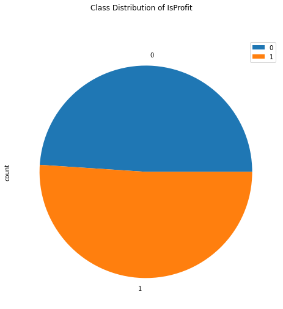

```python
class_counts = pd.DataFrame(df.groupby('isprofit').size(),columns=['count']).reset_index()
#class_counts = class_counts[class_counts['count']>=10].reset_index()
class_counts['percentage']=class_counts['count']/class_counts['count'].sum()*100
#ax = class_counts.plot(x='isprofit',y='count',kind='bar',title='Class Distribution of Genres',figsize=(16,5));
#[ax.text(i, class_counts.loc[i]['count'],'{:.2f}%'.format(class_counts.loc[i].percentage)) for i in class_counts.index];
ax = class_counts.plot(x='isprofit',y='count',kind='pie',title='Class Distribution of IsProfit',
                       figsize=(8,8),subplots=True, labels=class_counts.isprofit);
```

```python
for i in class_counts.index:
    if (class_counts.loc[i].percentage/100)>=0.25:
        print(str(class_counts.loc[i]['isprofit']) + " is balanced")
    elif (class_counts.loc[i].percentage/100)>=0.1:
        print(str(class_counts.loc[i]['isprofit']) + " is Slightly Imbalance")
    else:
        print(str(class_counts.loc[i]['isprofit']) + " is Severely Imbalance")
```

```
0.0 is balanced
1.0 is balanced
```

### 2.2.2. Categorical Feature Dependency Using Chi-Square Test

```python
columns = ["genre", "company", "country", "director", "rating", "year_released", "isprofit"]
```

Our data has the following columns that we can use to conduct the chi-square test on:

- Genre
- Company
- Country
- Director
- Rating
- Released
- Isprofit

  > We want to find out whether two categorical attributes are independent or dependent by using the chi-square test. We do this by getting all combinations of length two from the list above and conducting the chi-square test on each of the categorical pairs.  
  > After writing some general formulas, we will conduct the test on all 21 combinations.

#### 2.2.2.1. Chi-square Test for Each Feature

Below, we iterate over all the possible pairs of our 7 categorical features and perform a chi-square test on each pair. At the end, we summarize the results by indicating which pairs are dependent and which are not.

```python
### # Get all combinations of columns array of length 2, C(7, 2) = 21 combinations
comb = it.combinations(columns, 2)
res=[]
for i in list(comb):
    # Contingency Table
    table = pd.crosstab(df[i[0]], df[i[1]])
    display(table)

    # Observed Values
    Observed_Values = table.values
    print("Observed Values")
    display(Observed_Values)

    # Calculate Chi-Squared test
    # Returns of scipy.state.chi2_contigency()
    # chi2: The test statistic
    # p: The p-value of the test
    # dof: Degrees of freedom
    # expected: The expected frequencies, based on the marginal sums of the table

    chi2_test_statistic, p, dof, expected = sp.chi2_contingency(table)
    print("chi2_test_statistic, p, dof, expected")
    display(chi2_test_statistic, p, dof, expected)

    # interpret test statistic

    # Test Statistic >= Critical Value: reject null hypotheses, dependent (Ha)
    # Test Statistic < Critical Value: fail to reject null hypotheses, independent (Ho)
    # chi2.ppf(q, df, loc=0, scale=1) inverset CDF

    prob = 0.95 # significant value = 1 - 0.95 = 0.05
    critical = chi2.ppf(prob, dof)
    print("critical = %.3f, chi2_test_statistic = %.3f" % (critical, chi2_test_statistic))

    if chi2_test_statistic >= critical:
        print("Dependent (reject H0)\n")
    else:
        print("Independent (fail to reject H0)\n")

    # interpret p-value
    # p-value <= alpha: reject null hypothesis, dependent (Ha)
    # p-value: > alpha: fail to reject null hypothesis, independent (Ho)
    alpha = 1.0 - prob
    print("significance = %.3f, p = %.3f" % (alpha, p))
    dependent_p = False
    if p <= alpha:
        print("Dependent (reject H0)")
        dependent_p = True
    else:
        print("Independent (fail to reject H0)")

    res.append(list(i)+[dependent_p])
```

| company genre | Castle Rock Entertainment | Columbia Pictures | Columbia Pictures Corporation | Dimension Films | DreamWorks | Fox 2000 Pictures | Fox Searchlight Pictures | Hollywood Pictures | Metro-Goldwyn-Mayer (MGM) | Miramax | ... | Other | Paramount Pictures | Screen Gems | Summit Entertainment | Touchstone Pictures | TriStar Pictures | Twentieth Century Fox Film Corporation | Universal Pictures | Walt Disney Pictures | Warner Bros. |
| --- | --- | --- | --- | --- | --- | --- | --- | --- | --- | --- | --- | --- | --- | --- | --- | --- | --- | --- | --- | --- | --- |
| 0 | 0 | 0 | 0 | 0 | 0 | 0 | 0 | 0 | 0 | 0 | ... | 9 | 0 | 0 | 0 | 0 | 0 | 0 | 0 | 0 | 0 |
| Action | 6 | 28 | 36 | 6 | 10 | 3 | 1 | 7 | 11 | 3 | ... | 348 | 57 | 8 | 11 | 16 | 8 | 50 | 58 | 16 | 79 |
| Adventure | 2 | 5 | 7 | 1 | 4 | 7 | 3 | 2 | 3 | 2 | ... | 98 | 10 | 1 | 6 | 5 | 0 | 15 | 11 | 16 | 15 |
| Animation | 1 | 10 | 1 | 0 | 3 | 4 | 0 | 0 | 0 | 0 | ... | 98 | 9 | 0 | 0 | 3 | 0 | 7 | 5 | 14 | 12 |
| Biography | 0 | 6 | 8 | 0 | 3 | 3 | 6 | 3 | 1 | 1 | ... | 127 | 1 | 0 | 0 | 6 | 2 | 1 | 17 | 3 | 4 |
| Comedy | 18 | 19 | 30 | 12 | 21 | 18 | 16 | 12 | 26 | 21 | ... | 556 | 54 | 8 | 5 | 28 | 21 | 37 | 76 | 19 | 42 |
| Crime | 4 | 6 | 7 | 2 | 2 | 1 | 1 | 2 | 4 | 8 | ... | 156 | 15 | 4 | 1 | 2 | 5 | 3 | 11 | 0 | 17 |
| Drama | 6 | 9 | 22 | 1 | 15 | 10 | 7 | 4 | 13 | 10 | ... | 358 | 20 | 7 | 6 | 16 | 3 | 12 | 20 | 1 | 36 |
| Family | 0 | 0 | 0 | 0 | 0 | 0 | 0 | 0 | 0 | 0 | ... | 2 | 0 | 0 | 0 | 0 | 0 | 0 | 0 | 0 | 0 |
| Fantasy | 0 | 0 | 0 | 0 | 0 | 0 | 0 | 0 | 0 | 0 | ... | 8 | 4 | 0 | 0 | 0 | 2 | 0 | 1 | 0 | 0 |
| Horror | 0 | 3 | 3 | 12 | 2 | 0 | 0 | 1 | 2 | 0 | ... | 92 | 5 | 4 | 1 | 0 | 0 | 2 | 5 | 0 | 5 |
| Mystery | 0 | 2 | 3 | 0 | 1 | 0 | 0 | 0 | 0 | 0 | ... | 10 | 2 | 0 | 1 | 0 | 0 | 0 | 3 | 0 | 1 |
| Romance | 0 | 0 | 0 | 0 | 0 | 0 | 1 | 0 | 0 | 0 | ... | 2 | 0 | 0 | 0 | 0 | 0 | 0 | 1 | 0 | 0 |
| Sci-Fi | 0 | 0 | 0 | 0 | 0 | 0 | 0 | 0 | 0 | 0 | ... | 6 | 0 | 0 | 0 | 0 | 0 | 1 | 0 | 0 | 1 |
| Thriller | 0 | 0 | 0 | 0 | 0 | 0 | 0 | 0 | 0 | 0 | ... | 6 | 0 | 0 | 0 | 0 | 0 | 0 | 0 | 0 | 0 |
| Western | 0 | 0 | 0 | 0 | 0 | 0 | 0 | 0 | 0 | 0 | ... | 1 | 0 | 0 | 0 | 0 | 0 | 0 | 0 | 0 | 0 |

16 rows × 21 columns

```
Observed Values
```

```
array([[  0,   0,   0,   0,   0,   0,   0,   0,   0,   0,   0,   9,   0,
          0,   0,   0,   0,   0,   0,   0,   0],
       [  6,  28,  36,   6,  10,   3,   1,   7,  11,   3,  32, 348,  57,
          8,  11,  16,   8,  50,  58,  16,  79],
       [  2,   5,   7,   1,   4,   7,   3,   2,   3,   2,  10,  98,  10,
          1,   6,   5,   0,  15,  11,  16,  15],
       [  1,  10,   1,   0,   3,   4,   0,   0,   0,   0,   0,  98,   9,
          0,   0,   3,   0,   7,   5,  14,  12],
       [  0,   6,   8,   0,   3,   3,   6,   3,   1,   1,   1, 127,   1,
          0,   0,   6,   2,   1,  17,   3,   4],
       [ 18,  19,  30,  12,  21,  18,  16,  12,  26,  21,  35, 556,  54,
          8,   5,  28,  21,  37,  76,  19,  42],
       [  4,   6,   7,   2,   2,   1,   1,   2,   4,   8,  11, 156,  15,
          4,   1,   2,   5,   3,  11,   0,  17],
       [  6,   9,  22,   1,  15,  10,   7,   4,  13,  10,  13, 358,  20,
          7,   6,  16,   3,  12,  20,   1,  36],
       [  0,   0,   0,   0,   0,   0,   0,   0,   0,   0,   1,   2,   0,
          0,   0,   0,   0,   0,   0,   0,   0],
       [  0,   0,   0,   0,   0,   0,   0,   0,   0,   0,   4,   8,   4,
          0,   0,   0,   2,   0,   1,   0,   0],
       [  0,   3,   3,  12,   2,   0,   0,   1,   2,   0,  11,  92,   5,
          4,   1,   0,   0,   2,   5,   0,   5],
       [  0,   2,   3,   0,   1,   0,   0,   0,   0,   0,   1,  10,   2,
          0,   1,   0,   0,   0,   3,   0,   1],
       [  0,   0,   0,   0,   0,   0,   1,   0,   0,   0,   0,   2,   0,
          0,   0,   0,   0,   0,   1,   0,   0],
       [  0,   0,   0,   0,   0,   0,   0,   0,   0,   0,   0,   6,   0,
          0,   0,   0,   0,   1,   0,   0,   1],
       [  0,   0,   0,   0,   0,   0,   0,   0,   0,   0,   0,   6,   0,
          0,   0,   0,   0,   0,   0,   0,   0],
       [  0,   0,   0,   0,   0,   0,   0,   0,   0,   0,   0,   1,   0,
          0,   0,   0,   0,   0,   0,   0,   0]])
```

```
chi2_test_statistic, p, dof, expected
```

```
632.6359770327847
```

```
6.867936576941464e-26
```

```
300
```

[output not shown]

[output cut: 41 more lines]

```
        4.01816118e-01, 7.26447219e-02, 7.03745743e-02, 1.72531215e-01,
        9.30760499e-02, 2.90578888e-01, 4.72190692e-01, 1.56640182e-01,
        4.81271283e-01],
       [6.29965948e-02, 1.49829739e-01, 1.99205448e-01, 5.78887628e-02,
        1.03859251e-01, 7.83200908e-02, 5.95913734e-02, 5.27809308e-02,
        1.02156640e-01, 7.66174801e-02, 2.02610670e-01, 3.19580023e+00,
        3.01362089e-01, 5.44835414e-02, 5.27809308e-02, 1.29398411e-01,
        6.98070375e-02, 2.17934166e-01, 3.54143019e-01, 1.17480136e-01,
        3.60953462e-01],
       [1.04994325e-02, 2.49716232e-02, 3.32009081e-02, 9.64812713e-03,
        1.73098751e-02, 1.30533485e-02, 9.93189557e-03, 8.79682179e-03,
        1.70261067e-02, 1.27695800e-02, 3.37684449e-02, 5.32633371e-01,
        5.02270148e-02, 9.08059024e-03, 8.79682179e-03, 2.15664018e-02,
        1.16345062e-02, 3.63223610e-02, 5.90238365e-02, 1.95800227e-02,
        6.01589103e-02]])
```

```
critical = 341.395, chi2_test_statistic = 632.636
Dependent (reject H0)

significance = 0.050, p = 0.000
Dependent (reject H0)
```

| country genre | Other | USA |
| --- | --- | --- |
| 0 | 9 | 0 |
| Action | 100 | 694 |
| Adventure | 38 | 185 |
| Animation | 18 | 149 |
| Biography | 60 | 133 |
| Comedy | 101 | 973 |
| Crime | 29 | 233 |
| Drama | 117 | 472 |
| Family | 0 | 3 |
| Fantasy | 1 | 18 |
| Horror | 16 | 132 |
| Mystery | 3 | 21 |
| Romance | 2 | 2 |
| Sci-Fi | 1 | 7 |
| Thriller | 1 | 5 |
| Western | 1 | 0 |

```
Observed Values
```

```
array([[  9,   0],
       [100, 694],
       [ 38, 185],
       [ 18, 149],
       [ 60, 133],
       [101, 973],
       [ 29, 233],
       [117, 472],
       [  0,   3],
       [  1,  18],
       [ 16, 132],
       [  3,  21],
       [  2,   2],
       [  1,   7],
       [  1,   5],
       [  1,   0]])
```

```
chi2_test_statistic, p, dof, expected
```

```
156.57229777650653
```

```
1.1876526875042708e-25
```

```
15
```

```
array([[1.26929625e+00, 7.73070375e+00],
       [1.11980136e+02, 6.82019864e+02],
       [3.14503405e+01, 1.91549659e+02],
       [2.35524972e+01, 1.43447503e+02],
       [2.72193530e+01, 1.65780647e+02],
       [1.51469353e+02, 9.22530647e+02],
       [3.69506243e+01, 2.25049376e+02],
       [8.30683882e+01, 5.05931612e+02],
       [4.23098751e-01, 2.57690125e+00],
       [2.67962543e+00, 1.63203746e+01],
       [2.08728717e+01, 1.27127128e+02],
       [3.38479001e+00, 2.06152100e+01],
       [5.64131669e-01, 3.43586833e+00],
       [1.12826334e+00, 6.87173666e+00],
       [8.46197503e-01, 5.15380250e+00],
       [1.41032917e-01, 8.58967083e-01]])
```

```
critical = 24.996, chi2_test_statistic = 156.572
Dependent (reject H0)

significance = 0.050, p = 0.000
Dependent (reject H0)
```

| director genre | Barry Levinson | Bruce Beresford | Clint Eastwood | Dennis Dugan | Martin Scorsese | Michael Apted | Oliver Stone | Other | Renny Harlin | Richard Donner | ... | Ridley Scott | Rob Reiner | Robert Zemeckis | Ron Howard | Spike Lee | Steven Soderbergh | Steven Spielberg | Tim Burton | Wes Craven | Woody Allen |
| --- | --- | --- | --- | --- | --- | --- | --- | --- | --- | --- | --- | --- | --- | --- | --- | --- | --- | --- | --- | --- | --- |
| 0 | 0 | 0 | 0 | 0 | 0 | 0 | 0 | 9 | 0 | 0 | ... | 0 | 0 | 0 | 0 | 0 | 0 | 0 | 0 | 0 | 0 |
| Action | 0 | 0 | 5 | 3 | 0 | 1 | 1 | 749 | 10 | 9 | ... | 5 | 0 | 1 | 3 | 1 | 0 | 4 | 1 | 0 | 0 |
| Adventure | 1 | 0 | 1 | 0 | 1 | 1 | 0 | 197 | 0 | 0 | ... | 4 | 3 | 4 | 3 | 0 | 0 | 5 | 3 | 0 | 0 |
| Animation | 0 | 0 | 0 | 0 | 0 | 0 | 0 | 162 | 0 | 0 | ... | 0 | 0 | 2 | 0 | 0 | 0 | 1 | 1 | 0 | 0 |
| Biography | 2 | 1 | 6 | 0 | 2 | 2 | 5 | 165 | 0 | 0 | ... | 1 | 0 | 0 | 3 | 0 | 2 | 2 | 2 | 0 | 0 |
| Comedy | 4 | 3 | 0 | 8 | 0 | 1 | 0 | 994 | 0 | 1 | ... | 2 | 7 | 2 | 6 | 7 | 3 | 1 | 3 | 3 | 24 |
| Crime | 2 | 1 | 3 | 0 | 3 | 4 | 2 | 235 | 0 | 0 | ... | 2 | 1 | 0 | 0 | 3 | 5 | 1 | 0 | 0 | 0 |
| Drama | 3 | 5 | 5 | 0 | 3 | 1 | 6 | 531 | 0 | 1 | ... | 1 | 2 | 3 | 0 | 4 | 7 | 5 | 1 | 1 | 4 |
| Family | 0 | 0 | 0 | 0 | 0 | 0 | 0 | 3 | 0 | 0 | ... | 0 | 0 | 0 | 0 | 0 | 0 | 0 | 0 | 0 | 0 |
| Fantasy | 0 | 0 | 0 | 0 | 0 | 0 | 0 | 16 | 0 | 0 | ... | 0 | 0 | 0 | 0 | 0 | 0 | 0 | 1 | 2 | 0 |
| Horror | 0 | 0 | 0 | 0 | 0 | 0 | 0 | 141 | 2 | 0 | ... | 0 | 0 | 0 | 0 | 0 | 0 | 0 | 0 | 5 | 0 |
| Mystery | 0 | 0 | 0 | 0 | 1 | 0 | 0 | 20 | 0 | 0 | ... | 0 | 0 | 0 | 2 | 0 | 0 | 0 | 0 | 1 | 0 |
| Romance | 0 | 0 | 0 | 0 | 0 | 0 | 0 | 4 | 0 | 0 | ... | 0 | 0 | 0 | 0 | 0 | 0 | 0 | 0 | 0 | 0 |
| Sci-Fi | 0 | 0 | 0 | 0 | 0 | 0 | 0 | 8 | 0 | 0 | ... | 0 | 0 | 0 | 0 | 0 | 0 | 0 | 0 | 0 | 0 |
| Thriller | 0 | 0 | 0 | 0 | 0 | 0 | 0 | 6 | 0 | 0 | ... | 0 | 0 | 0 | 0 | 0 | 0 | 0 | 0 | 0 | 0 |
| Western | 0 | 0 | 0 | 0 | 0 | 0 | 0 | 1 | 0 | 0 | ... | 0 | 0 | 0 | 0 | 0 | 0 | 0 | 0 | 0 | 0 |

16 rows × 21 columns

```
Observed Values
```

```
array([[  0,   0,   0,   0,   0,   0,   0,   9,   0,   0,   0,   0,   0,
          0,   0,   0,   0,   0,   0,   0,   0],
       [  0,   0,   5,   3,   0,   1,   1, 749,  10,   9,   1,   5,   0,
          1,   3,   1,   0,   4,   1,   0,   0],
       [  1,   0,   1,   0,   1,   1,   0, 197,   0,   0,   0,   4,   3,
          4,   3,   0,   0,   5,   3,   0,   0],
       [  0,   0,   0,   0,   0,   0,   0, 162,   0,   0,   1,   0,   0,
          2,   0,   0,   0,   1,   1,   0,   0],
       [  2,   1,   6,   0,   2,   2,   5, 165,   0,   0,   0,   1,   0,
          0,   3,   0,   2,   2,   2,   0,   0],
       [  4,   3,   0,   8,   0,   1,   0, 994,   0,   1,   5,   2,   7,
          2,   6,   7,   3,   1,   3,   3,  24],
       [  2,   1,   3,   0,   3,   4,   2, 235,   0,   0,   0,   2,   1,
          0,   0,   3,   5,   1,   0,   0,   0],
       [  3,   5,   5,   0,   3,   1,   6, 531,   0,   1,   6,   1,   2,
          3,   0,   4,   7,   5,   1,   1,   4],
       [  0,   0,   0,   0,   0,   0,   0,   3,   0,   0,   0,   0,   0,
          0,   0,   0,   0,   0,   0,   0,   0],
       [  0,   0,   0,   0,   0,   0,   0,  16,   0,   0,   0,   0,   0,
          0,   0,   0,   0,   0,   1,   2,   0],
       [  0,   0,   0,   0,   0,   0,   0, 141,   2,   0,   0,   0,   0,
          0,   0,   0,   0,   0,   0,   5,   0],
       [  0,   0,   0,   0,   1,   0,   0,  20,   0,   0,   0,   0,   0,
          0,   2,   0,   0,   0,   0,   1,   0],
       [  0,   0,   0,   0,   0,   0,   0,   4,   0,   0,   0,   0,   0,
          0,   0,   0,   0,   0,   0,   0,   0],
       [  0,   0,   0,   0,   0,   0,   0,   8,   0,   0,   0,   0,   0,
          0,   0,   0,   0,   0,   0,   0,   0],
       [  0,   0,   0,   0,   0,   0,   0,   6,   0,   0,   0,   0,   0,
          0,   0,   0,   0,   0,   0,   0,   0],
       [  0,   0,   0,   0,   0,   0,   0,   1,   0,   0,   0,   0,   0,
          0,   0,   0,   0,   0,   0,   0,   0]])
```

```
chi2_test_statistic, p, dof, expected
```

```
561.0515094746818
```

```
4.588799305328769e-18
```

```
300
```

[output not shown]

[output cut: 41 more lines]

```
        2.95119183e-02, 2.72417707e-02, 3.85925085e-02, 3.40522134e-02,
        3.85925085e-02, 4.31328036e-02, 2.72417707e-02, 2.72417707e-02,
        6.35641317e-02],
       [2.04313280e-02, 1.70261067e-02, 3.40522134e-02, 1.87287174e-02,
        1.70261067e-02, 1.70261067e-02, 2.38365494e-02, 5.51816118e+00,
        2.04313280e-02, 1.87287174e-02, 2.21339387e-02, 2.55391600e-02,
        2.21339387e-02, 2.04313280e-02, 2.89443814e-02, 2.55391600e-02,
        2.89443814e-02, 3.23496027e-02, 2.04313280e-02, 2.04313280e-02,
        4.76730988e-02],
       [3.40522134e-03, 2.83768445e-03, 5.67536890e-03, 3.12145289e-03,
        2.83768445e-03, 2.83768445e-03, 3.97275823e-03, 9.19693530e-01,
        3.40522134e-03, 3.12145289e-03, 3.68898978e-03, 4.25652667e-03,
        3.68898978e-03, 3.40522134e-03, 4.82406356e-03, 4.25652667e-03,
        4.82406356e-03, 5.39160045e-03, 3.40522134e-03, 3.40522134e-03,
        7.94551646e-03]])
```

```
critical = 341.395, chi2_test_statistic = 561.052
Dependent (reject H0)

significance = 0.050, p = 0.000
Dependent (reject H0)
```

| rating genre | 0 | G | NC-17 | NOT RATED | Not specified | PG | PG-13 | R | UNRATED |
| --- | --- | --- | --- | --- | --- | --- | --- | --- | --- |
| 0 | 9 | 0 | 0 | 0 | 0 | 0 | 0 | 0 | 0 |
| Action | 0 | 0 | 0 | 1 | 2 | 67 | 362 | 362 | 0 |
| Adventure | 0 | 11 | 0 | 0 | 0 | 90 | 77 | 45 | 0 |
| Animation | 0 | 47 | 0 | 0 | 0 | 109 | 6 | 5 | 0 |
| Biography | 0 | 1 | 0 | 2 | 0 | 27 | 64 | 97 | 2 |
| Comedy | 0 | 8 | 3 | 7 | 0 | 177 | 405 | 470 | 4 |
| Crime | 0 | 0 | 1 | 0 | 0 | 0 | 26 | 233 | 2 |
| Drama | 0 | 1 | 1 | 12 | 1 | 40 | 215 | 314 | 5 |
| Family | 0 | 1 | 0 | 0 | 0 | 2 | 0 | 0 | 0 |
| Fantasy | 0 | 0 | 0 | 1 | 0 | 1 | 0 | 17 | 0 |
| Horror | 0 | 0 | 0 | 0 | 0 | 0 | 29 | 119 | 0 |
| Mystery | 0 | 0 | 0 | 1 | 0 | 0 | 10 | 13 | 0 |
| Romance | 0 | 0 | 0 | 0 | 0 | 2 | 2 | 0 | 0 |
| Sci-Fi | 0 | 0 | 0 | 0 | 0 | 0 | 6 | 2 | 0 |
| Thriller | 0 | 0 | 0 | 0 | 0 | 1 | 0 | 5 | 0 |
| Western | 0 | 0 | 0 | 0 | 0 | 0 | 0 | 1 | 0 |

```
Observed Values
```

```
array([[  9,   0,   0,   0,   0,   0,   0,   0,   0],
       [  0,   0,   0,   1,   2,  67, 362, 362,   0],
       [  0,  11,   0,   0,   0,  90,  77,  45,   0],
       [  0,  47,   0,   0,   0, 109,   6,   5,   0],
       [  0,   1,   0,   2,   0,  27,  64,  97,   2],
       [  0,   8,   3,   7,   0, 177, 405, 470,   4],
       [  0,   0,   1,   0,   0,   0,  26, 233,   2],
       [  0,   1,   1,  12,   1,  40, 215, 314,   5],
       [  0,   1,   0,   0,   0,   2,   0,   0,   0],
       [  0,   0,   0,   1,   0,   1,   0,  17,   0],
       [  0,   0,   0,   0,   0,   0,  29, 119,   0],
       [  0,   0,   0,   1,   0,   0,  10,  13,   0],
       [  0,   0,   0,   0,   0,   2,   2,   0,   0],
       [  0,   0,   0,   0,   0,   0,   6,   2,   0],
       [  0,   0,   0,   0,   0,   1,   0,   5,   0],
       [  0,   0,   0,   0,   0,   0,   0,   1,   0]])
```

```
chi2_test_statistic, p, dof, expected
```

```
5155.835279456919
```

```
0.0
```

```
120
```

[output not shown]

```
critical = 146.567, chi2_test_statistic = 5155.835
Dependent (reject H0)

significance = 0.050, p = 0.000
Dependent (reject H0)
```

| year_released genre | 1986 | 1987 | 1988 | 1989 | 1990 | 1991 | 1992 | 1993 | 1994 | 1995 | ... | 2008 | 2009 | 2010 | 2011 | 2012 | 2013 | 2014 | 2015 | 2016 | 2017 |
| --- | --- | --- | --- | --- | --- | --- | --- | --- | --- | --- | --- | --- | --- | --- | --- | --- | --- | --- | --- | --- | --- |
| 0 | 0 | 0 | 0 | 0 | 0 | 0 | 0 | 0 | 0 | 0 | ... | 0 | 0 | 0 | 0 | 0 | 0 | 0 | 0 | 0 | 0 |
| Action | 21 | 21 | 15 | 19 | 24 | 26 | 11 | 18 | 22 | 28 | ... | 35 | 23 | 36 | 30 | 34 | 39 | 27 | 31 | 22 | 9 |
| Adventure | 9 | 4 | 3 | 10 | 5 | 4 | 9 | 8 | 3 | 5 | ... | 10 | 12 | 9 | 8 | 11 | 6 | 9 | 5 | 6 | 1 |
| Animation | 2 | 0 | 3 | 1 | 1 | 0 | 1 | 3 | 3 | 2 | ... | 7 | 10 | 8 | 10 | 6 | 8 | 7 | 8 | 10 | 0 |
| Biography | 2 | 2 | 5 | 1 | 3 | 2 | 2 | 5 | 6 | 4 | ... | 7 | 9 | 7 | 6 | 7 | 13 | 7 | 12 | 12 | 4 |
| Comedy | 24 | 21 | 31 | 27 | 22 | 29 | 24 | 24 | 44 | 35 | ... | 40 | 33 | 33 | 37 | 35 | 25 | 31 | 26 | 28 | 2 |
| Crime | 2 | 5 | 7 | 7 | 5 | 7 | 11 | 11 | 9 | 12 | ... | 13 | 6 | 9 | 2 | 5 | 9 | 10 | 6 | 5 | 0 |
| Drama | 4 | 8 | 15 | 6 | 10 | 12 | 17 | 20 | 10 | 17 | ... | 21 | 19 | 22 | 29 | 20 | 18 | 24 | 26 | 14 | 4 |
| Family | 0 | 0 | 0 | 0 | 0 | 0 | 0 | 1 | 1 | 0 | ... | 0 | 0 | 0 | 0 | 0 | 0 | 0 | 0 | 0 | 0 |
| Fantasy | 0 | 2 | 1 | 2 | 1 | 0 | 1 | 2 | 1 | 2 | ... | 0 | 1 | 0 | 0 | 0 | 1 | 0 | 0 | 0 | 0 |
| Horror | 2 | 4 | 6 | 2 | 2 | 1 | 5 | 4 | 2 | 3 | ... | 9 | 5 | 4 | 6 | 10 | 7 | 7 | 6 | 5 | 1 |
| Mystery | 0 | 0 | 0 | 0 | 1 | 1 | 0 | 1 | 1 | 0 | ... | 0 | 2 | 1 | 3 | 0 | 0 | 2 | 0 | 0 | 0 |
| Romance | 0 | 0 | 0 | 0 | 0 | 0 | 0 | 0 | 0 | 0 | ... | 0 | 0 | 0 | 1 | 0 | 0 | 0 | 0 | 0 | 0 |
| Sci-Fi | 1 | 0 | 0 | 1 | 1 | 0 | 0 | 0 | 0 | 0 | ... | 0 | 0 | 0 | 0 | 1 | 0 | 0 | 1 | 0 | 0 |
| Thriller | 0 | 1 | 1 | 0 | 1 | 0 | 0 | 0 | 0 | 0 | ... | 0 | 1 | 0 | 0 | 0 | 0 | 0 | 0 | 1 | 0 |
| Western | 0 | 0 | 0 | 0 | 0 | 0 | 0 | 0 | 0 | 0 | ... | 0 | 0 | 0 | 0 | 0 | 0 | 0 | 1 | 0 | 0 |

16 rows × 32 columns

```
Observed Values
```

[output not shown]

```
chi2_test_statistic, p, dof, expected
```

```
726.5865368991151
```

```
8.360734331348754e-14
```

```
465
```

[output not shown]

[output cut: 73 more lines]

```
        1.29398411e-01, 1.39614075e-01, 1.37911464e-01, 1.65153235e-01,
        1.73666288e-01, 1.83881952e-01, 1.92395006e-01, 2.14528944e-01,
        2.00908059e-01, 2.28149830e-01, 2.31555051e-01, 2.23041998e-01,
        2.41770715e-01, 2.24744608e-01, 2.21339387e-01, 1.94097616e-01,
        2.11123723e-01, 2.23041998e-01, 2.41770715e-01, 2.06015891e-01,
        2.19636776e-01, 2.24744608e-01, 2.19636776e-01, 2.14528944e-01,
        2.11123723e-01, 2.07718502e-01, 1.75368899e-01, 3.57548241e-02],
       [1.90124858e-02, 1.92962543e-02, 2.46878547e-02, 2.15664018e-02,
        2.15664018e-02, 2.32690125e-02, 2.29852440e-02, 2.75255392e-02,
        2.89443814e-02, 3.06469921e-02, 3.20658343e-02, 3.57548241e-02,
        3.34846765e-02, 3.80249716e-02, 3.85925085e-02, 3.71736663e-02,
        4.02951192e-02, 3.74574347e-02, 3.68898978e-02, 3.23496027e-02,
        3.51872872e-02, 3.71736663e-02, 4.02951192e-02, 3.43359818e-02,
        3.66061294e-02, 3.74574347e-02, 3.66061294e-02, 3.57548241e-02,
        3.51872872e-02, 3.46197503e-02, 2.92281498e-02, 5.95913734e-03]])
```

```
critical = 516.272, chi2_test_statistic = 726.587
Dependent (reject H0)

significance = 0.050, p = 0.000
Dependent (reject H0)
```

| isprofit genre | 0 | 1 |
| --- | --- | --- |
| 0 | 9 | 0 |
| Action | 426 | 368 |
| Adventure | 101 | 122 |
| Animation | 64 | 103 |
| Biography | 108 | 85 |
| Comedy | 474 | 600 |
| Crime | 140 | 122 |
| Drama | 327 | 262 |
| Family | 3 | 0 |
| Fantasy | 5 | 14 |
| Horror | 48 | 100 |
| Mystery | 9 | 15 |
| Romance | 2 | 2 |
| Sci-Fi | 4 | 4 |
| Thriller | 4 | 2 |
| Western | 1 | 0 |

```
Observed Values
```

```
array([[  9,   0],
       [426, 368],
       [101, 122],
       [ 64, 103],
       [108,  85],
       [474, 600],
       [140, 122],
       [327, 262],
       [  3,   0],
       [  5,  14],
       [ 48, 100],
       [  9,  15],
       [  2,   2],
       [  4,   4],
       [  4,   2],
       [  1,   0]])
```

```
chi2_test_statistic, p, dof, expected
```

```
77.43533448482708
```

```
2.0497069292208742e-10
```

```
15
```

```
array([[4.40550511e+00, 4.59449489e+00],
       [3.88663451e+02, 4.05336549e+02],
       [1.09158627e+02, 1.13841373e+02],
       [8.17465948e+01, 8.52534052e+01],
       [9.44736095e+01, 9.85263905e+01],
       [5.25723610e+02, 5.48276390e+02],
       [1.28249149e+02, 1.33750851e+02],
       [2.88315834e+02, 3.00684166e+02],
       [1.46850170e+00, 1.53149830e+00],
       [9.30051078e+00, 9.69948922e+00],
       [7.24460840e+01, 7.55539160e+01],
       [1.17480136e+01, 1.22519864e+01],
       [1.95800227e+00, 2.04199773e+00],
       [3.91600454e+00, 4.08399546e+00],
       [2.93700341e+00, 3.06299659e+00],
       [4.89500568e-01, 5.10499432e-01]])
```

```
critical = 24.996, chi2_test_statistic = 77.435
Dependent (reject H0)

significance = 0.050, p = 0.000
Dependent (reject H0)
```

| country company | Other | USA |
| --- | --- | --- |
| Castle Rock Entertainment | 2 | 35 |
| Columbia Pictures | 7 | 81 |
| Columbia Pictures Corporation | 6 | 111 |
| Dimension Films | 0 | 34 |
| DreamWorks | 2 | 59 |
| Fox 2000 Pictures | 1 | 45 |
| Fox Searchlight Pictures | 5 | 30 |
| Hollywood Pictures | 1 | 30 |
| Metro-Goldwyn-Mayer (MGM) | 6 | 54 |
| Miramax | 7 | 38 |
| New Line Cinema | 10 | 109 |
| Other | 373 | 1504 |
| Paramount Pictures | 9 | 168 |
| Screen Gems | 0 | 32 |
| Summit Entertainment | 1 | 30 |
| Touchstone Pictures | 6 | 70 |
| TriStar Pictures | 1 | 40 |
| Twentieth Century Fox Film Corporation | 9 | 119 |
| Universal Pictures | 27 | 181 |
| Walt Disney Pictures | 4 | 65 |
| Warner Bros. | 20 | 192 |

```
Observed Values
```

```
array([[   2,   35],
       [   7,   81],
       [   6,  111],
       [   0,   34],
       [   2,   59],
       [   1,   45],
       [   5,   30],
       [   1,   30],
       [   6,   54],
       [   7,   38],
       [  10,  109],
       [ 373, 1504],
       [   9,  168],
       [   0,   32],
       [   1,   30],
       [   6,   70],
       [   1,   40],
       [   9,  119],
       [  27,  181],
       [   4,   65],
       [  20,  192]])
```

```
chi2_test_statistic, p, dof, expected
```

```
128.8536092427827
```

```
6.393766101906721e-18
```

```
20
```

```
array([[   5.21821793,   31.78178207],
       [  12.41089671,   75.58910329],
       [  16.50085131,  100.49914869],
       [   4.79511918,   29.20488082],
       [   8.60300795,   52.39699205],
       [   6.48751419,   39.51248581],
       [   4.9361521 ,   30.0638479 ],
       [   4.37202043,   26.62797957],
       [   8.46197503,   51.53802497],
       [   6.34648127,   38.65351873],
       [  16.78291714,  102.21708286],
       [ 264.71878547, 1612.28121453],
       [  24.96282633,  152.03717367],
       [   4.51305335,   27.48694665],
       [   4.37202043,   26.62797957],
       [  10.7185017 ,   65.2814983 ],
       [   5.7823496 ,   35.2176504 ],
       [  18.05221339,  109.94778661],
       [  29.33484677,  178.66515323],
       [   9.73127128,   59.26872872],
       [  29.89897843,  182.10102157]])
```

```
critical = 31.410, chi2_test_statistic = 128.854
Dependent (reject H0)

significance = 0.050, p = 0.000
Dependent (reject H0)
```

| director company | Barry Levinson | Bruce Beresford | Clint Eastwood | Dennis Dugan | Martin Scorsese | Michael Apted | Oliver Stone | Other | Renny Harlin | Richard Donner | ... | Ridley Scott | Rob Reiner | Robert Zemeckis | Ron Howard | Spike Lee | Steven Soderbergh | Steven Spielberg | Tim Burton | Wes Craven | Woody Allen |
| --- | --- | --- | --- | --- | --- | --- | --- | --- | --- | --- | --- | --- | --- | --- | --- | --- | --- | --- | --- | --- | --- |
| Castle Rock Entertainment | 0 | 0 | 1 | 0 | 0 | 1 | 0 | 28 | 0 | 0 | ... | 0 | 5 | 1 | 0 | 0 | 0 | 0 | 0 | 0 | 0 |
| Columbia Pictures | 0 | 0 | 0 | 5 | 0 | 0 | 0 | 80 | 0 | 0 | ... | 0 | 0 | 0 | 2 | 0 | 0 | 1 | 0 | 0 | 0 |
| Columbia Pictures Corporation | 0 | 0 | 0 | 1 | 0 | 1 | 0 | 109 | 0 | 1 | ... | 1 | 2 | 0 | 0 | 1 | 0 | 0 | 1 | 0 | 0 |
| Dimension Films | 0 | 0 | 0 | 0 | 0 | 0 | 0 | 30 | 0 | 0 | ... | 0 | 0 | 0 | 0 | 0 | 0 | 0 | 0 | 4 | 0 |
| DreamWorks | 0 | 0 | 1 | 0 | 0 | 0 | 0 | 46 | 0 | 0 | ... | 1 | 0 | 1 | 0 | 0 | 0 | 7 | 0 | 1 | 4 |
| Fox 2000 Pictures | 0 | 0 | 0 | 0 | 0 | 2 | 0 | 43 | 0 | 0 | ... | 1 | 0 | 0 | 0 | 0 | 0 | 0 | 0 | 0 | 0 |
| Fox Searchlight Pictures | 0 | 0 | 0 | 0 | 0 | 0 | 0 | 34 | 0 | 0 | ... | 0 | 0 | 0 | 0 | 1 | 0 | 0 | 0 | 0 | 0 |
| Hollywood Pictures | 0 | 0 | 0 | 0 | 0 | 0 | 0 | 30 | 0 | 0 | ... | 1 | 0 | 0 | 0 | 0 | 0 | 0 | 0 | 0 | 0 |
| Metro-Goldwyn-Mayer (MGM) | 0 | 1 | 0 | 0 | 0 | 0 | 0 | 57 | 0 | 0 | ... | 1 | 0 | 0 | 1 | 0 | 0 | 0 | 0 | 0 | 0 |
| Miramax | 0 | 0 | 0 | 0 | 1 | 0 | 0 | 41 | 0 | 0 | ... | 0 | 0 | 0 | 0 | 0 | 1 | 0 | 0 | 0 | 2 |
| New Line Cinema | 0 | 0 | 0 | 0 | 0 | 1 | 0 | 115 | 1 | 0 | ... | 0 | 0 | 0 | 0 | 1 | 0 | 0 | 0 | 1 | 0 |
| Other | 8 | 8 | 10 | 2 | 3 | 2 | 7 | 1762 | 7 | 2 | ... | 4 | 3 | 2 | 5 | 6 | 9 | 2 | 3 | 4 | 19 |
| Paramount Pictures | 0 | 1 | 0 | 0 | 2 | 1 | 1 | 161 | 0 | 2 | ... | 0 | 0 | 2 | 1 | 0 | 0 | 3 | 1 | 0 | 0 |
| Screen Gems | 0 | 0 | 0 | 0 | 0 | 0 | 0 | 32 | 0 | 0 | ... | 0 | 0 | 0 | 0 | 0 | 0 | 0 | 0 | 0 | 0 |
| Summit Entertainment | 0 | 0 | 0 | 0 | 0 | 0 | 0 | 30 | 1 | 0 | ... | 0 | 0 | 0 | 0 | 0 | 0 | 0 | 0 | 0 | 0 |
| Touchstone Pictures | 1 | 0 | 0 | 0 | 1 | 0 | 0 | 70 | 0 | 0 | ... | 0 | 0 | 1 | 0 | 1 | 0 | 0 | 1 | 0 | 1 |
| TriStar Pictures | 1 | 0 | 0 | 0 | 0 | 1 | 0 | 37 | 0 | 0 | ... | 0 | 0 | 0 | 0 | 0 | 0 | 0 | 0 | 0 | 2 |
| Twentieth Century Fox Film Corporation | 0 | 0 | 0 | 0 | 0 | 0 | 2 | 116 | 2 | 0 | ... | 3 | 0 | 1 | 0 | 0 | 0 | 1 | 2 | 0 | 0 |
| Universal Pictures | 0 | 0 | 0 | 3 | 2 | 1 | 0 | 178 | 0 | 0 | ... | 1 | 1 | 3 | 7 | 5 | 2 | 3 | 0 | 2 | 0 |
| Walt Disney Pictures | 0 | 0 | 0 | 0 | 0 | 0 | 0 | 68 | 0 | 0 | ... | 0 | 0 | 0 | 0 | 0 | 0 | 1 | 0 | 0 | 0 |
| Warner Bros. | 2 | 0 | 8 | 0 | 1 | 0 | 4 | 174 | 1 | 6 | ... | 2 | 2 | 1 | 1 | 0 | 5 | 1 | 4 | 0 | 0 |

21 rows × 21 columns

```
Observed Values
```

[output not shown]

```
chi2_test_statistic, p, dof, expected
```

```
1089.9807821717773
```

```
2.8563531972245992e-65
```

```
400
```

[output not shown]

[output cut: 71 more lines]

```
        7.67309875e-01, 7.08286039e-01, 1.00340522e+00, 8.85357548e-01,
        1.00340522e+00, 1.12145289e+00, 7.08286039e-01, 7.08286039e-01,
        1.65266742e+00],
       [2.34960272e-01, 1.95800227e-01, 3.91600454e-01, 2.15380250e-01,
        1.95800227e-01, 1.95800227e-01, 2.74120318e-01, 6.34588536e+01,
        2.34960272e-01, 2.15380250e-01, 2.54540295e-01, 2.93700341e-01,
        2.54540295e-01, 2.34960272e-01, 3.32860386e-01, 2.93700341e-01,
        3.32860386e-01, 3.72020431e-01, 2.34960272e-01, 2.34960272e-01,
        5.48240636e-01],
       [7.21906924e-01, 6.01589103e-01, 1.20317821e+00, 6.61748014e-01,
        6.01589103e-01, 6.01589103e-01, 8.42224745e-01, 1.94975028e+02,
        7.21906924e-01, 6.61748014e-01, 7.82065834e-01, 9.02383655e-01,
        7.82065834e-01, 7.21906924e-01, 1.02270148e+00, 9.02383655e-01,
        1.02270148e+00, 1.14301930e+00, 7.21906924e-01, 7.21906924e-01,
        1.68444949e+00]])
```

```
critical = 447.632, chi2_test_statistic = 1089.981
Dependent (reject H0)

significance = 0.050, p = 0.000
Dependent (reject H0)
```

| rating company | 0 | G | NC-17 | NOT RATED | Not specified | PG | PG-13 | R | UNRATED |
| --- | --- | --- | --- | --- | --- | --- | --- | --- | --- |
| Castle Rock Entertainment | 0 | 1 | 0 | 0 | 0 | 5 | 15 | 16 | 0 |
| Columbia Pictures | 0 | 0 | 0 | 0 | 0 | 20 | 43 | 25 | 0 |
| Columbia Pictures Corporation | 0 | 0 | 0 | 0 | 0 | 10 | 54 | 53 | 0 |
| Dimension Films | 0 | 0 | 0 | 0 | 0 | 1 | 10 | 23 | 0 |
| DreamWorks | 0 | 0 | 0 | 0 | 0 | 6 | 33 | 22 | 0 |
| Fox 2000 Pictures | 0 | 2 | 0 | 0 | 0 | 18 | 18 | 8 | 0 |
| Fox Searchlight Pictures | 0 | 0 | 1 | 0 | 0 | 2 | 6 | 26 | 0 |
| Hollywood Pictures | 0 | 0 | 0 | 0 | 0 | 7 | 10 | 14 | 0 |
| Metro-Goldwyn-Mayer (MGM) | 0 | 0 | 0 | 0 | 0 | 11 | 28 | 21 | 0 |
| Miramax | 0 | 0 | 0 | 0 | 0 | 4 | 11 | 30 | 0 |
| New Line Cinema | 0 | 1 | 0 | 0 | 0 | 7 | 43 | 68 | 0 |
| Other | 9 | 40 | 4 | 24 | 3 | 239 | 492 | 1053 | 13 |
| Paramount Pictures | 0 | 3 | 0 | 0 | 0 | 24 | 85 | 65 | 0 |
| Screen Gems | 0 | 0 | 0 | 0 | 0 | 0 | 20 | 12 | 0 |
| Summit Entertainment | 0 | 0 | 0 | 0 | 0 | 2 | 23 | 6 | 0 |
| Touchstone Pictures | 0 | 1 | 0 | 0 | 0 | 16 | 38 | 21 | 0 |
| TriStar Pictures | 0 | 0 | 0 | 0 | 0 | 6 | 13 | 22 | 0 |
| Twentieth Century Fox Film Corporation | 0 | 1 | 0 | 0 | 0 | 24 | 67 | 36 | 0 |
| Universal Pictures | 0 | 2 | 0 | 0 | 0 | 29 | 105 | 72 | 0 |
| Walt Disney Pictures | 0 | 18 | 0 | 0 | 0 | 44 | 7 | 0 | 0 |
| Warner Bros. | 0 | 0 | 0 | 0 | 0 | 41 | 81 | 90 | 0 |

```
Observed Values
```

```
array([[   0,    1,    0,    0,    0,    5,   15,   16,    0],
       [   0,    0,    0,    0,    0,   20,   43,   25,    0],
       [   0,    0,    0,    0,    0,   10,   54,   53,    0],
       [   0,    0,    0,    0,    0,    1,   10,   23,    0],
       [   0,    0,    0,    0,    0,    6,   33,   22,    0],
       [   0,    2,    0,    0,    0,   18,   18,    8,    0],
       [   0,    0,    1,    0,    0,    2,    6,   26,    0],
       [   0,    0,    0,    0,    0,    7,   10,   14,    0],
       [   0,    0,    0,    0,    0,   11,   28,   21,    0],
       [   0,    0,    0,    0,    0,    4,   11,   30,    0],
       [   0,    1,    0,    0,    0,    7,   43,   68,    0],
       [   9,   40,    4,   24,    3,  239,  492, 1053,   13],
       [   0,    3,    0,    0,    0,   24,   85,   65,    0],
       [   0,    0,    0,    0,    0,    0,   20,   12,    0],
       [   0,    0,    0,    0,    0,    2,   23,    6,    0],
       [   0,    1,    0,    0,    0,   16,   38,   21,    0],
       [   0,    0,    0,    0,    0,    6,   13,   22,    0],
       [   0,    1,    0,    0,    0,   24,   67,   36,    0],
       [   0,    2,    0,    0,    0,   29,  105,   72,    0],
       [   0,   18,    0,    0,    0,   44,    7,    0,    0],
       [   0,    0,    0,    0,    0,   41,   81,   90,    0]])
```

```
chi2_test_statistic, p, dof, expected
```

```
731.5286210479003
```

```
6.267700202785287e-74
```

```
160
```

[output not shown]

[output cut: 8 more lines]

```
       [1.04710556e-01, 8.02780931e-01, 5.81725312e-02, 2.79228150e-01,
        3.49035187e-02, 6.00340522e+00, 1.39846765e+01, 1.95808740e+01,
        1.51248581e-01],
       [3.26901249e-01, 2.50624291e+00, 1.81611805e-01, 8.71736663e-01,
        1.08967083e-01, 1.87423383e+01, 4.36594779e+01, 6.11305335e+01,
        4.72190692e-01],
       [5.31214529e-01, 4.07264472e+00, 2.95119183e-01, 1.41657208e+00,
        1.77071510e-01, 3.04562997e+01, 7.09466515e+01, 9.93371169e+01,
        7.67309875e-01],
       [1.76220204e-01, 1.35102157e+00, 9.79001135e-02, 4.69920545e-01,
        5.87400681e-02, 1.01032917e+01, 2.35351873e+01, 3.29531782e+01,
        2.54540295e-01],
       [5.41430193e-01, 4.15096481e+00, 3.00794552e-01, 1.44381385e+00,
        1.80476731e-01, 3.10419977e+01, 7.23110102e+01, 1.01247446e+02,
        7.82065834e-01]])
```

```
critical = 190.516, chi2_test_statistic = 731.529
Dependent (reject H0)

significance = 0.050, p = 0.000
Dependent (reject H0)
```

| year_released company | 1986 | 1987 | 1988 | 1989 | 1990 | 1991 | 1992 | 1993 | 1994 | 1995 | ... | 2008 | 2009 | 2010 | 2011 | 2012 | 2013 | 2014 | 2015 | 2016 | 2017 |
| --- | --- | --- | --- | --- | --- | --- | --- | --- | --- | --- | --- | --- | --- | --- | --- | --- | --- | --- | --- | --- | --- |
| Castle Rock Entertainment | 0 | 0 | 0 | 1 | 1 | 1 | 2 | 1 | 2 | 2 | ... | 0 | 0 | 1 | 0 | 0 | 0 | 0 | 0 | 0 | 0 |
| Columbia Pictures | 0 | 1 | 1 | 0 | 0 | 0 | 0 | 0 | 0 | 1 | ... | 10 | 10 | 7 | 9 | 8 | 8 | 4 | 5 | 4 | 0 |
| Columbia Pictures Corporation | 3 | 3 | 3 | 5 | 2 | 5 | 6 | 9 | 2 | 4 | ... | 0 | 1 | 0 | 0 | 0 | 0 | 0 | 0 | 0 | 0 |
| Dimension Films | 0 | 0 | 0 | 0 | 0 | 0 | 0 | 0 | 0 | 0 | ... | 1 | 0 | 2 | 2 | 1 | 1 | 0 | 0 | 0 | 0 |
| DreamWorks | 0 | 0 | 0 | 0 | 0 | 0 | 0 | 0 | 0 | 0 | ... | 5 | 4 | 2 | 4 | 3 | 1 | 1 | 1 | 0 | 0 |
| Fox 2000 Pictures | 0 | 0 | 0 | 0 | 0 | 0 | 0 | 0 | 0 | 0 | ... | 2 | 3 | 4 | 4 | 3 | 2 | 1 | 3 | 1 | 0 |
| Fox Searchlight Pictures | 0 | 0 | 0 | 0 | 0 | 0 | 0 | 0 | 0 | 0 | ... | 3 | 1 | 2 | 1 | 2 | 2 | 1 | 0 | 1 | 0 |
| Hollywood Pictures | 0 | 0 | 0 | 0 | 1 | 2 | 3 | 3 | 2 | 6 | ... | 0 | 0 | 0 | 0 | 0 | 0 | 0 | 0 | 0 | 0 |
| Metro-Goldwyn-Mayer (MGM) | 1 | 0 | 5 | 0 | 1 | 1 | 1 | 4 | 3 | 2 | ... | 4 | 1 | 1 | 0 | 0 | 1 | 0 | 1 | 0 | 0 |
| Miramax | 0 | 0 | 0 | 0 | 0 | 0 | 0 | 0 | 2 | 6 | ... | 0 | 0 | 0 | 0 | 0 | 0 | 0 | 1 | 0 | 0 |
| New Line Cinema | 1 | 1 | 2 | 2 | 0 | 2 | 1 | 4 | 6 | 3 | ... | 6 | 3 | 2 | 3 | 3 | 4 | 2 | 0 | 5 | 0 |
| Other | 40 | 50 | 53 | 47 | 48 | 45 | 43 | 49 | 52 | 53 | ... | 69 | 60 | 63 | 59 | 79 | 78 | 93 | 89 | 75 | 21 |
| Paramount Pictures | 8 | 4 | 5 | 6 | 4 | 7 | 5 | 6 | 7 | 7 | ... | 6 | 3 | 5 | 10 | 6 | 5 | 4 | 3 | 2 | 0 |
| Screen Gems | 0 | 0 | 0 | 0 | 0 | 0 | 0 | 0 | 0 | 0 | ... | 4 | 2 | 4 | 2 | 2 | 0 | 1 | 0 | 1 | 0 |
| Summit Entertainment | 0 | 0 | 0 | 0 | 0 | 0 | 0 | 0 | 0 | 0 | ... | 2 | 2 | 6 | 6 | 3 | 4 | 3 | 2 | 1 | 0 |
| Touchstone Pictures | 3 | 0 | 4 | 3 | 2 | 3 | 4 | 3 | 2 | 1 | ... | 2 | 2 | 2 | 1 | 0 | 1 | 0 | 0 | 0 | 0 |
| TriStar Pictures | 2 | 1 | 1 | 3 | 2 | 4 | 2 | 3 | 2 | 6 | ... | 0 | 0 | 0 | 2 | 0 | 3 | 0 | 0 | 1 | 0 |
| Twentieth Century Fox Film Corporation | 3 | 1 | 3 | 0 | 4 | 3 | 3 | 5 | 4 | 3 | ... | 5 | 5 | 7 | 4 | 4 | 3 | 4 | 4 | 6 | 0 |
| Universal Pictures | 2 | 3 | 6 | 4 | 6 | 5 | 3 | 4 | 7 | 8 | ... | 10 | 13 | 8 | 13 | 6 | 7 | 3 | 5 | 2 | 0 |
| Walt Disney Pictures | 2 | 0 | 0 | 0 | 0 | 1 | 1 | 2 | 3 | 1 | ... | 3 | 2 | 4 | 4 | 1 | 2 | 3 | 1 | 1 | 0 |
| Warner Bros. | 2 | 4 | 4 | 5 | 5 | 3 | 7 | 4 | 8 | 5 | ... | 10 | 9 | 9 | 8 | 8 | 4 | 4 | 7 | 3 | 0 |

21 rows × 32 columns

```
Observed Values
```

[output not shown]

```
chi2_test_statistic, p, dof, expected
```

```
1048.0378039712941
```

```
1.7352783815447647e-24
```

```
620
```

[output not shown]

[output cut: 92 more lines]

[output not shown]

```
critical = 679.036, chi2_test_statistic = 1048.038
Dependent (reject H0)

significance = 0.050, p = 0.000
Dependent (reject H0)
```

| isprofit company | 0 | 1 |
| --- | --- | --- |
| Castle Rock Entertainment | 18 | 19 |
| Columbia Pictures | 33 | 55 |
| Columbia Pictures Corporation | 58 | 59 |
| Dimension Films | 12 | 22 |
| DreamWorks | 29 | 32 |
| Fox 2000 Pictures | 18 | 28 |
| Fox Searchlight Pictures | 11 | 24 |
| Hollywood Pictures | 13 | 18 |
| Metro-Goldwyn-Mayer (MGM) | 36 | 24 |
| Miramax | 21 | 24 |
| New Line Cinema | 42 | 77 |
| Other | 1044 | 833 |
| Paramount Pictures | 59 | 118 |
| Screen Gems | 10 | 22 |
| Summit Entertainment | 11 | 20 |
| Touchstone Pictures | 26 | 50 |
| TriStar Pictures | 17 | 24 |
| Twentieth Century Fox Film Corporation | 53 | 75 |
| Universal Pictures | 90 | 118 |
| Walt Disney Pictures | 19 | 50 |
| Warner Bros. | 105 | 107 |

```
Observed Values
```

```
array([[  18,   19],
       [  33,   55],
       [  58,   59],
       [  12,   22],
       [  29,   32],
       [  18,   28],
       [  11,   24],
       [  13,   18],
       [  36,   24],
       [  21,   24],
       [  42,   77],
       [1044,  833],
       [  59,  118],
       [  10,   22],
       [  11,   20],
       [  26,   50],
       [  17,   24],
       [  53,   75],
       [  90,  118],
       [  19,   50],
       [ 105,  107]])
```

```
chi2_test_statistic, p, dof, expected
```

```
108.59106965831063
```

```
3.54619926405531e-14
```

```
20
```

```
array([[ 18.111521  ,  18.888479  ],
       [ 43.07604994,  44.92395006],
       [ 57.2715664 ,  59.7284336 ],
       [ 16.6430193 ,  17.3569807 ],
       [ 29.85953462,  31.14046538],
       [ 22.51702611,  23.48297389],
       [ 17.13251986,  17.86748014],
       [ 15.17451759,  15.82548241],
       [ 29.37003405,  30.62996595],
       [ 22.02752554,  22.97247446],
       [ 58.25056754,  60.74943246],
       [918.79256527, 958.20743473],
       [ 86.64160045,  90.35839955],
       [ 15.66401816,  16.33598184],
       [ 15.17451759,  15.82548241],
       [ 37.20204313,  38.79795687],
       [ 20.06952327,  20.93047673],
       [ 62.65607264,  65.34392736],
       [101.81611805, 106.18388195],
       [ 33.77553916,  35.22446084],
       [103.77412032, 108.22587968]])
```

```
critical = 31.410, chi2_test_statistic = 108.591
Dependent (reject H0)

significance = 0.050, p = 0.000
Dependent (reject H0)
```

| director country | Barry Levinson | Bruce Beresford | Clint Eastwood | Dennis Dugan | Martin Scorsese | Michael Apted | Oliver Stone | Other | Renny Harlin | Richard Donner | ... | Ridley Scott | Rob Reiner | Robert Zemeckis | Ron Howard | Spike Lee | Steven Soderbergh | Steven Spielberg | Tim Burton | Wes Craven | Woody Allen |
| --- | --- | --- | --- | --- | --- | --- | --- | --- | --- | --- | --- | --- | --- | --- | --- | --- | --- | --- | --- | --- | --- |
| Other | 0 | 4 | 1 | 0 | 2 | 1 | 4 | 472 | 0 | 1 | ... | 2 | 0 | 1 | 0 | 0 | 2 | 1 | 1 | 0 | 4 |
| USA | 12 | 6 | 19 | 11 | 8 | 9 | 10 | 2769 | 12 | 10 | ... | 13 | 13 | 11 | 17 | 15 | 15 | 18 | 11 | 12 | 24 |

2 rows × 21 columns

```
Observed Values
```

```
array([[   0,    4,    1,    0,    2,    1,    4,  472,    0,    1,    1,
           2,    0,    1,    0,    0,    2,    1,    1,    0,    4],
       [  12,    6,   19,   11,    8,    9,   10, 2769,   12,   10,   12,
          13,   13,   11,   17,   15,   15,   18,   11,   12,   24]])
```

```
chi2_test_statistic, p, dof, expected
```

```
28.06027075879496
```

```
0.10798029507256064
```

```
20
```

```
array([[1.69239501e+00, 1.41032917e+00, 2.82065834e+00, 1.55136209e+00,
        1.41032917e+00, 1.41032917e+00, 1.97446084e+00, 4.57087684e+02,
        1.69239501e+00, 1.55136209e+00, 1.83342792e+00, 2.11549376e+00,
        1.83342792e+00, 1.69239501e+00, 2.39755959e+00, 2.11549376e+00,
        2.39755959e+00, 2.67962543e+00, 1.69239501e+00, 1.69239501e+00,
        3.94892168e+00],
       [1.03076050e+01, 8.58967083e+00, 1.71793417e+01, 9.44863791e+00,
        8.58967083e+00, 8.58967083e+00, 1.20255392e+01, 2.78391232e+03,
        1.03076050e+01, 9.44863791e+00, 1.11665721e+01, 1.28845062e+01,
        1.11665721e+01, 1.03076050e+01, 1.46024404e+01, 1.28845062e+01,
        1.46024404e+01, 1.63203746e+01, 1.03076050e+01, 1.03076050e+01,
        2.40510783e+01]])
```

```
critical = 31.410, chi2_test_statistic = 28.060
Independent (fail to reject H0)

significance = 0.050, p = 0.108
Independent (fail to reject H0)
```

| rating country | 0 | G | NC-17 | NOT RATED | Not specified | PG | PG-13 | R | UNRATED |
| --- | --- | --- | --- | --- | --- | --- | --- | --- | --- |
| Other | 9 | 13 | 1 | 13 | 2 | 61 | 141 | 253 | 4 |
| USA | 0 | 56 | 4 | 11 | 1 | 455 | 1061 | 1430 | 9 |

```
Observed Values
```

```
array([[   9,   13,    1,   13,    2,   61,  141,  253,    4],
       [   0,   56,    4,   11,    1,  455, 1061, 1430,    9]])
```

```
chi2_test_statistic, p, dof, expected
```

```
106.86195191438502
```

```
1.6790128058106214e-19
```

```
8
```

```
array([[1.26929625e+00, 9.73127128e+00, 7.05164586e-01, 3.38479001e+00,
        4.23098751e-01, 7.27729852e+01, 1.69521566e+02, 2.37358400e+02,
        1.83342792e+00],
       [7.73070375e+00, 5.92687287e+01, 4.29483541e+00, 2.06152100e+01,
        2.57690125e+00, 4.43227015e+02, 1.03247843e+03, 1.44564160e+03,
        1.11665721e+01]])
```

```
critical = 15.507, chi2_test_statistic = 106.862
Dependent (reject H0)

significance = 0.050, p = 0.000
Dependent (reject H0)
```

| year_released country | 1986 | 1987 | 1988 | 1989 | 1990 | 1991 | 1992 | 1993 | 1994 | 1995 | ... | 2008 | 2009 | 2010 | 2011 | 2012 | 2013 | 2014 | 2015 | 2016 | 2017 |
| --- | --- | --- | --- | --- | --- | --- | --- | --- | --- | --- | --- | --- | --- | --- | --- | --- | --- | --- | --- | --- | --- |
| Other | 4 | 13 | 9 | 7 | 5 | 6 | 9 | 9 | 10 | 15 | ... | 21 | 18 | 20 | 18 | 18 | 15 | 17 | 24 | 23 | 9 |
| USA | 63 | 55 | 78 | 69 | 71 | 76 | 72 | 88 | 92 | 93 | ... | 121 | 103 | 109 | 114 | 111 | 111 | 107 | 98 | 80 | 12 |

2 rows × 32 columns

```
Observed Values
```

```
array([[  4,  13,   9,   7,   5,   6,   9,   9,  10,  15,  12,  25,  11,
         23,  18,  15,  21,  18,  25,  19,  23,  17,  21,  18,  20,  18,
         18,  15,  17,  24,  23,   9],
       [ 63,  55,  78,  69,  71,  76,  72,  88,  92,  93, 101, 101, 107,
        111, 118, 116, 121, 114, 105,  95, 101, 114, 121, 103, 109, 114,
        111, 111, 107,  98,  80,  12]])
```

```
chi2_test_statistic, p, dof, expected
```

```
56.70000401429747
```

```
0.0032390635119746896
```

```
31
```

```
array([[  9.44920545,   9.59023837,  12.26986379,  10.7185017 ,
         10.7185017 ,  11.56469921,  11.42366629,  13.68019296,
         14.38535755,  15.23155505,  15.93671964,  17.77014756,
         16.64188422,  18.8984109 ,  19.18047673,  18.47531215,
         20.02667423,  18.61634506,  18.33427923,  16.07775255,
         17.48808173,  18.47531215,  20.02667423,  17.06498297,
         18.19324631,  18.61634506,  18.19324631,  17.77014756,
         17.48808173,  17.20601589,  14.52639047,   2.96169126],
       [ 57.55079455,  58.40976163,  74.73013621,  65.2814983 ,
         65.2814983 ,  70.43530079,  69.57633371,  83.31980704,
         87.61464245,  92.76844495,  97.06328036, 108.22985244,
        101.35811578, 115.1015891 , 116.81952327, 112.52468785,
        121.97332577, 113.38365494, 111.66572077,  97.92224745,
        106.51191827, 112.52468785, 121.97332577, 103.93501703,
        110.80675369, 113.38365494, 110.80675369, 108.22985244,
        106.51191827, 104.79398411,  88.47360953,  18.03830874]])
```

```
critical = 44.985, chi2_test_statistic = 56.700
Dependent (reject H0)

significance = 0.050, p = 0.003
Dependent (reject H0)
```

| isprofit country | 0 | 1 |
| --- | --- | --- |
| Other | 330 | 167 |
| USA | 1395 | 1632 |

```
Observed Values
```

```
array([[ 330,  167],
       [1395, 1632]])
```

```
chi2_test_statistic, p, dof, expected
```

```
69.68137484569843
```

```
6.970116776098656e-17
```

```
1
```

```
array([[ 243.28178207,  253.71821793],
       [1481.71821793, 1545.28178207]])
```

```
critical = 3.841, chi2_test_statistic = 69.681
Dependent (reject H0)

significance = 0.050, p = 0.000
Dependent (reject H0)
```

| rating director | 0 | G | NC-17 | NOT RATED | Not specified | PG | PG-13 | R | UNRATED |
| --- | --- | --- | --- | --- | --- | --- | --- | --- | --- |
| Barry Levinson | 0 | 0 | 0 | 0 | 0 | 0 | 2 | 10 | 0 |
| Bruce Beresford | 0 | 0 | 0 | 0 | 0 | 2 | 3 | 5 | 0 |
| Clint Eastwood | 0 | 0 | 0 | 0 | 0 | 1 | 7 | 12 | 0 |
| Dennis Dugan | 0 | 0 | 0 | 0 | 0 | 2 | 9 | 0 | 0 |
| Martin Scorsese | 0 | 0 | 0 | 0 | 0 | 1 | 1 | 8 | 0 |
| Michael Apted | 0 | 0 | 0 | 0 | 0 | 2 | 4 | 4 | 0 |
| Oliver Stone | 0 | 0 | 0 | 0 | 0 | 0 | 3 | 11 | 0 |
| Other | 9 | 68 | 5 | 23 | 3 | 484 | 1097 | 1539 | 13 |
| Renny Harlin | 0 | 0 | 0 | 0 | 0 | 0 | 4 | 8 | 0 |
| Richard Donner | 0 | 0 | 0 | 0 | 0 | 1 | 4 | 6 | 0 |
| Richard Linklater | 0 | 0 | 0 | 0 | 0 | 0 | 4 | 9 | 0 |
| Ridley Scott | 0 | 0 | 0 | 0 | 0 | 0 | 5 | 10 | 0 |
| Rob Reiner | 0 | 0 | 0 | 0 | 0 | 2 | 6 | 5 | 0 |
| Robert Zemeckis | 0 | 1 | 0 | 0 | 0 | 5 | 4 | 2 | 0 |
| Ron Howard | 0 | 0 | 0 | 0 | 0 | 3 | 10 | 4 | 0 |
| Spike Lee | 0 | 0 | 0 | 0 | 0 | 0 | 1 | 14 | 0 |
| Steven Soderbergh | 0 | 0 | 0 | 1 | 0 | 0 | 6 | 10 | 0 |
| Steven Spielberg | 0 | 0 | 0 | 0 | 0 | 4 | 11 | 4 | 0 |
| Tim Burton | 0 | 0 | 0 | 0 | 0 | 3 | 7 | 2 | 0 |
| Wes Craven | 0 | 0 | 0 | 0 | 0 | 1 | 1 | 10 | 0 |
| Woody Allen | 0 | 0 | 0 | 0 | 0 | 5 | 13 | 10 | 0 |

```
Observed Values
```

```
array([[   0,    0,    0,    0,    0,    0,    2,   10,    0],
       [   0,    0,    0,    0,    0,    2,    3,    5,    0],
       [   0,    0,    0,    0,    0,    1,    7,   12,    0],
       [   0,    0,    0,    0,    0,    2,    9,    0,    0],
       [   0,    0,    0,    0,    0,    1,    1,    8,    0],
       [   0,    0,    0,    0,    0,    2,    4,    4,    0],
       [   0,    0,    0,    0,    0,    0,    3,   11,    0],
       [   9,   68,    5,   23,    3,  484, 1097, 1539,   13],
       [   0,    0,    0,    0,    0,    0,    4,    8,    0],
       [   0,    0,    0,    0,    0,    1,    4,    6,    0],
       [   0,    0,    0,    0,    0,    0,    4,    9,    0],
       [   0,    0,    0,    0,    0,    0,    5,   10,    0],
       [   0,    0,    0,    0,    0,    2,    6,    5,    0],
       [   0,    1,    0,    0,    0,    5,    4,    2,    0],
       [   0,    0,    0,    0,    0,    3,   10,    4,    0],
       [   0,    0,    0,    0,    0,    0,    1,   14,    0],
       [   0,    0,    0,    1,    0,    0,    6,   10,    0],
       [   0,    0,    0,    0,    0,    4,   11,    4,    0],
       [   0,    0,    0,    0,    0,    3,    7,    2,    0],
       [   0,    0,    0,    0,    0,    1,    1,   10,    0],
       [   0,    0,    0,    0,    0,    5,   13,   10,    0]])
```

```
chi2_test_statistic, p, dof, expected
```

```
109.42592092116308
```

```
0.9992045661618998
```

```
160
```

```
array([[3.06469921e-02, 2.34960272e-01, 1.70261067e-02, 8.17253121e-02,
        1.02156640e-02, 1.75709421e+00, 4.09307605e+00, 5.73098751e+00,
        4.42678774e-02],
       [2.55391600e-02, 1.95800227e-01, 1.41884222e-02, 6.81044268e-02,
        8.51305335e-03, 1.46424518e+00, 3.41089671e+00, 4.77582293e+00,
        3.68898978e-02],
       [5.10783201e-02, 3.91600454e-01, 2.83768445e-02, 1.36208854e-01,
        1.70261067e-02, 2.92849035e+00, 6.82179342e+00, 9.55164586e+00,
        7.37797957e-02],
       [2.80930760e-02, 2.15380250e-01, 1.56072645e-02, 7.49148695e-02,
        9.36435868e-03, 1.61066969e+00, 3.75198638e+00, 5.25340522e+00,
        4.05788876e-02],
       [2.55391600e-02, 1.95800227e-01, 1.41884222e-02, 6.81044268e-02,
        8.51305335e-03, 1.46424518e+00, 3.41089671e+00, 4.77582293e+00,
        3.68898978e-02],
       [2.55391600e-02, 1.95800227e-01, 1.41884222e-02, 6.81044268e-02,
        8.51305335e-03, 1.46424518e+00, 3.41089671e+00, 4.77582293e+00,
        3.68898978e-02],
       [3.57548241e-02, 2.74120318e-01, 1.98637911e-02, 9.53461975e-02,
        1.19182747e-02, 2.04994325e+00, 4.77525539e+00, 6.68615210e+00,
        5.16458570e-02],
       [8.27724177e+00, 6.34588536e+01, 4.59846765e+00, 2.20726447e+01,
        2.75908059e+00, 4.74561862e+02, 1.10547162e+03, 1.54784421e+03,
        1.19560159e+01],
       [3.06469921e-02, 2.34960272e-01, 1.70261067e-02, 8.17253121e-02,
        1.02156640e-02, 1.75709421e+00, 4.09307605e+00, 5.73098751e+00,
        4.42678774e-02],
       [2.80930760e-02, 2.15380250e-01, 1.56072645e-02, 7.49148695e-02,
        9.36435868e-03, 1.61066969e+00, 3.75198638e+00, 5.25340522e+00,
        4.05788876e-02],
       [3.32009081e-02, 2.54540295e-01, 1.84449489e-02, 8.85357548e-02,
        1.10669694e-02, 1.90351873e+00, 4.43416572e+00, 6.20856981e+00,
        4.79568672e-02],
       [3.83087401e-02, 2.93700341e-01, 2.12826334e-02, 1.02156640e-01,
        1.27695800e-02, 2.19636776e+00, 5.11634506e+00, 7.16373439e+00,
        5.53348468e-02],
       [3.32009081e-02, 2.54540295e-01, 1.84449489e-02, 8.85357548e-02,
        1.10669694e-02, 1.90351873e+00, 4.43416572e+00, 6.20856981e+00,
        4.79568672e-02],
       [3.06469921e-02, 2.34960272e-01, 1.70261067e-02, 8.17253121e-02,
```

[output cut: 8 more lines]

```
       [4.34165721e-02, 3.32860386e-01, 2.41203178e-02, 1.15777526e-01,
        1.44721907e-02, 2.48921680e+00, 5.79852440e+00, 8.11889898e+00,
        6.27128263e-02],
       [4.85244041e-02, 3.72020431e-01, 2.69580023e-02, 1.29398411e-01,
        1.61748014e-02, 2.78206583e+00, 6.48070375e+00, 9.07406356e+00,
        7.00908059e-02],
       [3.06469921e-02, 2.34960272e-01, 1.70261067e-02, 8.17253121e-02,
        1.02156640e-02, 1.75709421e+00, 4.09307605e+00, 5.73098751e+00,
        4.42678774e-02],
       [3.06469921e-02, 2.34960272e-01, 1.70261067e-02, 8.17253121e-02,
        1.02156640e-02, 1.75709421e+00, 4.09307605e+00, 5.73098751e+00,
        4.42678774e-02],
       [7.15096481e-02, 5.48240636e-01, 3.97275823e-02, 1.90692395e-01,
        2.38365494e-02, 4.09988649e+00, 9.55051078e+00, 1.33723042e+01,
        1.03291714e-01]])
```

```
critical = 190.516, chi2_test_statistic = 109.426
Independent (fail to reject H0)

significance = 0.050, p = 0.999
Independent (fail to reject H0)
```

| year_released director | 1986 | 1987 | 1988 | 1989 | 1990 | 1991 | 1992 | 1993 | 1994 | 1995 | ... | 2008 | 2009 | 2010 | 2011 | 2012 | 2013 | 2014 | 2015 | 2016 | 2017 |
| --- | --- | --- | --- | --- | --- | --- | --- | --- | --- | --- | --- | --- | --- | --- | --- | --- | --- | --- | --- | --- | --- |
| Barry Levinson | 0 | 1 | 2 | 0 | 0 | 1 | 1 | 0 | 2 | 0 | ... | 1 | 0 | 0 | 0 | 0 | 0 | 0 | 1 | 0 | 0 |
| Bruce Beresford | 0 | 1 | 0 | 0 | 1 | 0 | 0 | 1 | 2 | 0 | ... | 0 | 0 | 0 | 0 | 0 | 0 | 0 | 0 | 1 | 0 |
| Clint Eastwood | 1 | 0 | 1 | 0 | 1 | 0 | 0 | 1 | 0 | 1 | ... | 1 | 2 | 1 | 1 | 0 | 0 | 1 | 1 | 1 | 0 |
| Dennis Dugan | 0 | 0 | 0 | 0 | 1 | 0 | 0 | 0 | 0 | 0 | ... | 1 | 0 | 1 | 2 | 0 | 1 | 0 | 0 | 0 | 0 |
| Martin Scorsese | 1 | 0 | 0 | 0 | 0 | 0 | 0 | 0 | 0 | 1 | ... | 0 | 0 | 1 | 1 | 0 | 1 | 0 | 0 | 0 | 0 |
| Michael Apted | 0 | 1 | 1 | 0 | 0 | 0 | 1 | 0 | 2 | 0 | ... | 0 | 0 | 1 | 0 | 1 | 0 | 0 | 0 | 0 | 0 |
| Oliver Stone | 0 | 2 | 0 | 1 | 1 | 2 | 0 | 0 | 1 | 0 | ... | 1 | 0 | 1 | 0 | 0 | 0 | 0 | 0 | 1 | 0 |
| Other | 60 | 58 | 75 | 65 | 66 | 72 | 71 | 91 | 87 | 97 | ... | 133 | 111 | 121 | 121 | 123 | 122 | 117 | 115 | 95 | 21 |
| Renny Harlin | 1 | 0 | 1 | 0 | 2 | 0 | 0 | 1 | 0 | 1 | ... | 0 | 1 | 0 | 0 | 0 | 0 | 1 | 0 | 0 | 0 |
| Richard Donner | 0 | 1 | 1 | 1 | 0 | 0 | 2 | 0 | 1 | 1 | ... | 0 | 0 | 0 | 0 | 0 | 0 | 0 | 0 | 0 | 0 |
| Richard Linklater | 0 | 0 | 0 | 0 | 0 | 1 | 0 | 0 | 1 | 1 | ... | 0 | 1 | 0 | 0 | 0 | 1 | 1 | 0 | 1 | 0 |
| Ridley Scott | 0 | 1 | 0 | 0 | 0 | 1 | 0 | 0 | 0 | 0 | ... | 1 | 0 | 0 | 0 | 1 | 0 | 1 | 1 | 0 | 0 |
| Rob Reiner | 1 | 1 | 0 | 1 | 1 | 0 | 1 | 0 | 0 | 1 | ... | 1 | 0 | 1 | 0 | 0 | 0 | 1 | 0 | 0 | 0 |
| Robert Zemeckis | 0 | 0 | 1 | 1 | 1 | 0 | 1 | 0 | 1 | 0 | ... | 0 | 0 | 0 | 0 | 1 | 0 | 0 | 1 | 1 | 0 |
| Ron Howard | 1 | 0 | 1 | 1 | 0 | 1 | 1 | 0 | 1 | 1 | ... | 0 | 2 | 0 | 1 | 0 | 0 | 0 | 1 | 0 | 0 |
| Spike Lee | 1 | 0 | 1 | 1 | 1 | 1 | 0 | 0 | 1 | 1 | ... | 1 | 0 | 0 | 0 | 0 | 0 | 0 | 0 | 0 | 0 |
| Steven Soderbergh | 0 | 0 | 0 | 1 | 0 | 1 | 0 | 1 | 0 | 0 | ... | 0 | 3 | 0 | 2 | 1 | 0 | 0 | 0 | 0 | 0 |
| Steven Spielberg | 0 | 1 | 0 | 1 | 0 | 1 | 0 | 1 | 1 | 0 | ... | 1 | 0 | 0 | 2 | 1 | 0 | 0 | 1 | 1 | 0 |
| Tim Burton | 0 | 0 | 1 | 0 | 1 | 0 | 1 | 0 | 1 | 0 | ... | 0 | 0 | 0 | 0 | 1 | 0 | 1 | 0 | 1 | 0 |
| Wes Craven | 0 | 0 | 1 | 1 | 0 | 1 | 0 | 0 | 1 | 1 | ... | 0 | 0 | 1 | 1 | 0 | 0 | 0 | 0 | 0 | 0 |
| Woody Allen | 1 | 1 | 1 | 2 | 0 | 0 | 2 | 1 | 0 | 2 | ... | 1 | 1 | 1 | 1 | 0 | 1 | 1 | 1 | 1 | 0 |

21 rows × 32 columns

```
Observed Values
```

```
array([[  0,   1,   2,   0,   0,   1,   1,   0,   2,   0,   1,   0,   2,
          0,   0,   0,   0,   0,   0,   0,   0,   0,   1,   0,   0,   0,
          0,   0,   0,   1,   0,   0],
       [  0,   1,   0,   0,   1,   0,   0,   1,   2,   0,   0,   1,   0,
          1,   0,   0,   2,   0,   0,   0,   0,   0,   0,   0,   0,   0,
          0,   0,   0,   0,   1,   0],
       [  1,   0,   1,   0,   1,   0,   0,   1,   0,   1,   0,   2,   0,
          0,   1,   0,   1,   1,   0,   1,   0,   1,   1,   2,   1,   1,
          0,   0,   1,   1,   1,   0],
       [  0,   0,   0,   0,   1,   0,   0,   0,   0,   0,   1,   0,   0,
          1,   0,   1,   0,   0,   0,   0,   1,   1,   1,   0,   1,   2,
          0,   1,   0,   0,   0,   0],
       [  1,   0,   0,   0,   0,   0,   0,   0,   0,   1,   0,   0,   1,
          1,   0,   0,   1,   0,   1,   0,   1,   0,   0,   0,   1,   1,
          0,   1,   0,   0,   0,   0],
       [  0,   1,   1,   0,   0,   0,   1,   0,   2,   0,   1,   0,   0,
          1,   0,   0,   1,   0,   0,   0,   0,   0,   0,   0,   1,   0,
          1,   0,   0,   0,   0,   0],
       [  0,   2,   0,   1,   1,   2,   0,   0,   1,   0,   1,   0,   0,
          1,   0,   0,   0,   0,   1,   0,   1,   0,   1,   0,   1,   0,
          0,   0,   0,   0,   1,   0],
       [ 60,  58,  75,  65,  66,  72,  71,  91,  87,  97, 104, 115, 108,
        122, 126, 125, 131, 124, 121, 105, 113, 126, 133, 111, 121, 121,
        123, 122, 117, 115,  95,  21],
       [  1,   0,   1,   0,   2,   0,   0,   1,   0,   1,   1,   0,   0,
          1,   0,   1,   0,   0,   1,   0,   0,   0,   0,   1,   0,   0,
          0,   0,   1,   0,   0,   0],
       [  0,   1,   1,   1,   0,   0,   2,   0,   1,   1,   0,   1,   1,
          0,   0,   0,   0,   1,   0,   0,   1,   0,   0,   0,   0,   0,
          0,   0,   0,   0,   0,   0],
       [  0,   0,   0,   0,   0,   1,   0,   0,   1,   1,   0,   0,   1,
          0,   0,   0,   1,   1,   1,   1,   1,   0,   0,   1,   0,   0,
          0,   1,   1,   0,   1,   0],
       [  0,   1,   0,   0,   0,   1,   0,   0,   0,   0,   1,   1,   0,
          0,   1,   1,   1,   1,   0,   1,   1,   1,   1,   0,   0,   0,
          1,   0,   1,   1,   0,   0],
       [  1,   1,   0,   1,   1,   0,   1,   0,   0,   1,   0,   1,   0,
          1,   0,   0,   0,   1,   0,   1,   0,   0,   1,   0,   1,   0,
          0,   0,   1,   0,   0,   0],
       [  0,   0,   1,   1,   1,   0,   1,   0,   1,   0,   0,   1,   0,
```

[output cut: 8 more lines]

```
       [  0,   0,   0,   1,   0,   1,   0,   1,   0,   0,   0,   0,   1,
          1,   1,   1,   1,   0,   1,   0,   0,   2,   0,   3,   0,   2,
          1,   0,   0,   0,   0,   0],
       [  0,   1,   0,   1,   0,   1,   0,   1,   1,   0,   0,   2,   1,
          0,   0,   1,   1,   0,   1,   1,   1,   0,   1,   0,   0,   2,
          1,   0,   0,   1,   1,   0],
       [  0,   0,   1,   0,   1,   0,   1,   0,   1,   0,   1,   0,   0,
          1,   0,   0,   0,   0,   1,   2,   0,   0,   0,   0,   0,   0,
          1,   0,   1,   0,   1,   0],
       [  0,   0,   1,   1,   0,   1,   0,   0,   1,   1,   1,   1,   0,
          1,   1,   0,   0,   0,   0,   1,   0,   0,   0,   0,   1,   1,
          0,   0,   0,   0,   0,   0],
       [  1,   1,   1,   2,   0,   0,   2,   1,   0,   2,   0,   1,   2,
          0,   2,   1,   1,   1,   0,   0,   2,   0,   1,   1,   1,   1,
          0,   1,   1,   1,   1,   0]])
```

```
chi2_test_statistic, p, dof, expected
```

```
510.73008095070855
```

```
0.9994946326596159
```

```
620
```

```
array([[2.28149830e-01, 2.31555051e-01, 2.96254257e-01, 2.58796822e-01,
        2.58796822e-01, 2.79228150e-01, 2.75822928e-01, 3.30306470e-01,
        3.47332577e-01, 3.67763905e-01, 3.84790011e-01, 4.29057889e-01,
        4.01816118e-01, 4.56299659e-01, 4.63110102e-01, 4.46083995e-01,
        4.83541430e-01, 4.49489217e-01, 4.42678774e-01, 3.88195233e-01,
        4.22247446e-01, 4.46083995e-01, 4.83541430e-01, 4.12031782e-01,
        4.39273553e-01, 4.49489217e-01, 4.39273553e-01, 4.29057889e-01,
        4.22247446e-01, 4.15437003e-01, 3.50737798e-01, 7.15096481e-02],
       [1.90124858e-01, 1.92962543e-01, 2.46878547e-01, 2.15664018e-01,
        2.15664018e-01, 2.32690125e-01, 2.29852440e-01, 2.75255392e-01,
        2.89443814e-01, 3.06469921e-01, 3.20658343e-01, 3.57548241e-01,
        3.34846765e-01, 3.80249716e-01, 3.85925085e-01, 3.71736663e-01,
        4.02951192e-01, 3.74574347e-01, 3.68898978e-01, 3.23496027e-01,
        3.51872872e-01, 3.71736663e-01, 4.02951192e-01, 3.43359818e-01,
        3.66061294e-01, 3.74574347e-01, 3.66061294e-01, 3.57548241e-01,
        3.51872872e-01, 3.46197503e-01, 2.92281498e-01, 5.95913734e-02],
       [3.80249716e-01, 3.85925085e-01, 4.93757094e-01, 4.31328036e-01,
        4.31328036e-01, 4.65380250e-01, 4.59704881e-01, 5.50510783e-01,
        5.78887628e-01, 6.12939841e-01, 6.41316686e-01, 7.15096481e-01,
        6.69693530e-01, 7.60499432e-01, 7.71850170e-01, 7.43473326e-01,
        8.05902384e-01, 7.49148695e-01, 7.37797957e-01, 6.46992054e-01,
        7.03745743e-01, 7.43473326e-01, 8.05902384e-01, 6.86719637e-01,
        7.32122588e-01, 7.49148695e-01, 7.32122588e-01, 7.15096481e-01,
        7.03745743e-01, 6.92395006e-01, 5.84562997e-01, 1.19182747e-01],
       [2.09137344e-01, 2.12258797e-01, 2.71566402e-01, 2.37230420e-01,
        2.37230420e-01, 2.55959137e-01, 2.52837684e-01, 3.02780931e-01,
        3.18388195e-01, 3.37116913e-01, 3.52724177e-01, 3.93303065e-01,
        3.68331442e-01, 4.18274688e-01, 4.24517594e-01, 4.08910329e-01,
        4.43246311e-01, 4.12031782e-01, 4.05788876e-01, 3.55845630e-01,
        3.87060159e-01, 4.08910329e-01, 4.43246311e-01, 3.77695800e-01,
        4.02667423e-01, 4.12031782e-01, 4.02667423e-01, 3.93303065e-01,
        3.87060159e-01, 3.80817253e-01, 3.21509648e-01, 6.55505108e-02],
       [1.90124858e-01, 1.92962543e-01, 2.46878547e-01, 2.15664018e-01,
        2.15664018e-01, 2.32690125e-01, 2.29852440e-01, 2.75255392e-01,
        2.89443814e-01, 3.06469921e-01, 3.20658343e-01, 3.57548241e-01,
        3.34846765e-01, 3.80249716e-01, 3.85925085e-01, 3.71736663e-01,
        4.02951192e-01, 3.74574347e-01, 3.68898978e-01, 3.23496027e-01,
        3.51872872e-01, 3.71736663e-01, 4.02951192e-01, 3.43359818e-01,
        3.66061294e-01, 3.74574347e-01, 3.66061294e-01, 3.57548241e-01,
        3.51872872e-01, 3.46197503e-01, 2.92281498e-01, 5.95913734e-02],
```

[output cut: 113 more lines]

```
        2.58796822e-01, 2.79228150e-01, 2.75822928e-01, 3.30306470e-01,
        3.47332577e-01, 3.67763905e-01, 3.84790011e-01, 4.29057889e-01,
        4.01816118e-01, 4.56299659e-01, 4.63110102e-01, 4.46083995e-01,
        4.83541430e-01, 4.49489217e-01, 4.42678774e-01, 3.88195233e-01,
        4.22247446e-01, 4.46083995e-01, 4.83541430e-01, 4.12031782e-01,
        4.39273553e-01, 4.49489217e-01, 4.39273553e-01, 4.29057889e-01,
        4.22247446e-01, 4.15437003e-01, 3.50737798e-01, 7.15096481e-02],
       [5.32349603e-01, 5.40295119e-01, 6.91259932e-01, 6.03859251e-01,
        6.03859251e-01, 6.51532350e-01, 6.43586833e-01, 7.70715096e-01,
        8.10442679e-01, 8.58115778e-01, 8.97843360e-01, 1.00113507e+00,
        9.37570942e-01, 1.06469921e+00, 1.08059024e+00, 1.04086266e+00,
        1.12826334e+00, 1.04880817e+00, 1.03291714e+00, 9.05788876e-01,
        9.85244041e-01, 1.04086266e+00, 1.12826334e+00, 9.61407491e-01,
        1.02497162e+00, 1.04880817e+00, 1.02497162e+00, 1.00113507e+00,
        9.85244041e-01, 9.69353008e-01, 8.18388195e-01, 1.66855846e-01]])
```

```
critical = 679.036, chi2_test_statistic = 510.730
Independent (fail to reject H0)

significance = 0.050, p = 0.999
Independent (fail to reject H0)
```

| isprofit director | 0 | 1 |
| --- | --- | --- |
| Barry Levinson | 5 | 7 |
| Bruce Beresford | 7 | 3 |
| Clint Eastwood | 8 | 12 |
| Dennis Dugan | 2 | 9 |
| Martin Scorsese | 5 | 5 |
| Michael Apted | 4 | 6 |
| Oliver Stone | 6 | 8 |
| Other | 1595 | 1646 |
| Renny Harlin | 8 | 4 |
| Richard Donner | 5 | 6 |
| Richard Linklater | 4 | 9 |
| Ridley Scott | 9 | 6 |
| Rob Reiner | 6 | 7 |
| Robert Zemeckis | 2 | 10 |
| Ron Howard | 8 | 9 |
| Spike Lee | 8 | 7 |
| Steven Soderbergh | 7 | 10 |
| Steven Spielberg | 5 | 14 |
| Tim Burton | 5 | 7 |
| Wes Craven | 4 | 8 |
| Woody Allen | 22 | 6 |

```
Observed Values
```

```
array([[   5,    7],
       [   7,    3],
       [   8,   12],
       [   2,    9],
       [   5,    5],
       [   4,    6],
       [   6,    8],
       [1595, 1646],
       [   8,    4],
       [   5,    6],
       [   4,    9],
       [   9,    6],
       [   6,    7],
       [   2,   10],
       [   8,    9],
       [   8,    7],
       [   7,   10],
       [   5,   14],
       [   5,    7],
       [   4,    8],
       [  22,    6]])
```

```
chi2_test_statistic, p, dof, expected
```

```
32.22157475338656
```

```
0.04099378720033222
```

```
20
```

```
array([[   5.87400681,    6.12599319],
       [   4.89500568,    5.10499432],
       [   9.79001135,   10.20998865],
       [   5.38450624,    5.61549376],
       [   4.89500568,    5.10499432],
       [   4.89500568,    5.10499432],
       [   6.85300795,    7.14699205],
       [1586.47133939, 1654.52866061],
       [   5.87400681,    6.12599319],
       [   5.38450624,    5.61549376],
       [   6.36350738,    6.63649262],
       [   7.34250851,    7.65749149],
       [   6.36350738,    6.63649262],
       [   5.87400681,    6.12599319],
       [   8.32150965,    8.67849035],
       [   7.34250851,    7.65749149],
       [   8.32150965,    8.67849035],
       [   9.30051078,    9.69948922],
       [   5.87400681,    6.12599319],
       [   5.87400681,    6.12599319],
       [  13.70601589,   14.29398411]])
```

```
critical = 31.410, chi2_test_statistic = 32.222
Dependent (reject H0)

significance = 0.050, p = 0.041
Dependent (reject H0)
```

| year_released rating | 1986 | 1987 | 1988 | 1989 | 1990 | 1991 | 1992 | 1993 | 1994 | 1995 | ... | 2008 | 2009 | 2010 | 2011 | 2012 | 2013 | 2014 | 2015 | 2016 | 2017 |
| --- | --- | --- | --- | --- | --- | --- | --- | --- | --- | --- | --- | --- | --- | --- | --- | --- | --- | --- | --- | --- | --- |
| 0 | 0 | 0 | 0 | 0 | 0 | 0 | 0 | 0 | 0 | 0 | ... | 0 | 0 | 0 | 0 | 0 | 0 | 0 | 0 | 0 | 0 |
| G | 1 | 0 | 2 | 2 | 1 | 0 | 1 | 2 | 3 | 2 | ... | 4 | 2 | 2 | 4 | 0 | 1 | 1 | 1 | 0 | 0 |
| NC-17 | 0 | 0 | 0 | 0 | 0 | 0 | 1 | 0 | 0 | 1 | ... | 0 | 0 | 0 | 0 | 0 | 0 | 0 | 0 | 0 | 0 |
| NOT RATED | 0 | 0 | 0 | 0 | 0 | 0 | 0 | 0 | 0 | 1 | ... | 1 | 2 | 0 | 2 | 3 | 0 | 5 | 1 | 0 | 0 |
| Not specified | 0 | 0 | 0 | 0 | 0 | 0 | 0 | 1 | 0 | 0 | ... | 0 | 0 | 0 | 0 | 0 | 0 | 0 | 1 | 0 | 0 |
| PG | 13 | 18 | 21 | 17 | 11 | 10 | 10 | 21 | 20 | 15 | ... | 16 | 20 | 23 | 18 | 13 | 8 | 18 | 16 | 10 | 3 |
| PG-13 | 24 | 11 | 16 | 18 | 17 | 18 | 23 | 31 | 31 | 21 | ... | 61 | 44 | 44 | 57 | 49 | 49 | 46 | 47 | 46 | 8 |
| R | 28 | 39 | 48 | 39 | 46 | 54 | 45 | 41 | 47 | 67 | ... | 60 | 53 | 60 | 51 | 63 | 68 | 54 | 55 | 46 | 10 |
| UNRATED | 1 | 0 | 0 | 0 | 1 | 0 | 1 | 1 | 1 | 1 | ... | 0 | 0 | 0 | 0 | 1 | 0 | 0 | 1 | 1 | 0 |

9 rows × 32 columns

```
Observed Values
```

```
array([[ 0,  0,  0,  0,  0,  0,  0,  0,  0,  0,  0,  9,  0,  0,  0,  0,
         0,  0,  0,  0,  0,  0,  0,  0,  0,  0,  0,  0,  0,  0,  0,  0],
       [ 1,  0,  2,  2,  1,  0,  1,  2,  3,  2,  2,  1,  4,  4,  7,  4,
         3,  2,  2,  4,  4,  3,  4,  2,  2,  4,  0,  1,  1,  1,  0,  0],
       [ 0,  0,  0,  0,  0,  0,  1,  0,  0,  1,  0,  0,  2,  0,  0,  0,
         0,  0,  1,  0,  0,  0,  0,  0,  0,  0,  0,  0,  0,  0,  0,  0],
       [ 0,  0,  0,  0,  0,  0,  0,  0,  0,  1,  1,  0,  0,  1,  1,  1,
         0,  1,  1,  0,  1,  2,  1,  2,  0,  2,  3,  0,  5,  1,  0,  0],
       [ 0,  0,  0,  0,  0,  0,  0,  1,  0,  0,  0,  0,  0,  0,  1,  0,
         0,  0,  0,  0,  0,  0,  0,  0,  0,  0,  0,  0,  0,  1,  0,  0],
       [13, 18, 21, 17, 11, 10, 10, 21, 20, 15, 18, 18, 16, 12, 16, 12,
        19, 16, 26, 20, 22, 20, 16, 20, 23, 18, 13,  8, 18, 16, 10,  3],
       [24, 11, 16, 18, 17, 18, 23, 31, 31, 21, 29, 28, 33, 39, 48, 51,
        55, 54, 56, 53, 49, 46, 61, 44, 44, 57, 49, 49, 46, 47, 46,  8],
       [28, 39, 48, 39, 46, 54, 45, 41, 47, 67, 63, 69, 63, 78, 63, 63,
        65, 59, 43, 36, 47, 60, 60, 53, 60, 51, 63, 68, 54, 55, 46, 10],
       [ 1,  0,  0,  0,  1,  0,  1,  1,  1,  1,  0,  1,  0,  0,  0,  0,
         0,  0,  1,  1,  1,  0,  0,  0,  0,  0,  1,  0,  0,  1,  1,  0]])
```

```
chi2_test_statistic, p, dof, expected
```

```
554.4002784894653
```

```
1.7586378004762064e-25
```

```
248
```

```
array([[1.71112372e-01, 1.73666288e-01, 2.22190692e-01, 1.94097616e-01,
        1.94097616e-01, 2.09421112e-01, 2.06867196e-01, 2.47729852e-01,
        2.60499432e-01, 2.75822928e-01, 2.88592509e-01, 3.21793417e-01,
        3.01362089e-01, 3.42224745e-01, 3.47332577e-01, 3.34562997e-01,
        3.62656073e-01, 3.37116913e-01, 3.32009081e-01, 2.91146425e-01,
        3.16685585e-01, 3.34562997e-01, 3.62656073e-01, 3.09023837e-01,
        3.29455165e-01, 3.37116913e-01, 3.29455165e-01, 3.21793417e-01,
        3.16685585e-01, 3.11577753e-01, 2.63053348e-01, 5.36322361e-02],
       [1.31186152e+00, 1.33144154e+00, 1.70346198e+00, 1.48808173e+00,
        1.48808173e+00, 1.60556186e+00, 1.58598184e+00, 1.89926220e+00,
        1.99716232e+00, 2.11464245e+00, 2.21254257e+00, 2.46708286e+00,
        2.31044268e+00, 2.62372304e+00, 2.66288309e+00, 2.56498297e+00,
        2.78036322e+00, 2.58456300e+00, 2.54540295e+00, 2.23212259e+00,
        2.42792281e+00, 2.56498297e+00, 2.78036322e+00, 2.36918275e+00,
        2.52582293e+00, 2.58456300e+00, 2.52582293e+00, 2.46708286e+00,
        2.42792281e+00, 2.38876277e+00, 2.01674234e+00, 4.11180477e-01],
       [9.50624291e-02, 9.64812713e-02, 1.23439274e-01, 1.07832009e-01,
        1.07832009e-01, 1.16345062e-01, 1.14926220e-01, 1.37627696e-01,
        1.44721907e-01, 1.53234960e-01, 1.60329171e-01, 1.78774120e-01,
        1.67423383e-01, 1.90124858e-01, 1.92962543e-01, 1.85868331e-01,
        2.01475596e-01, 1.87287174e-01, 1.84449489e-01, 1.61748014e-01,
        1.75936436e-01, 1.85868331e-01, 2.01475596e-01, 1.71679909e-01,
        1.83030647e-01, 1.87287174e-01, 1.83030647e-01, 1.78774120e-01,
        1.75936436e-01, 1.73098751e-01, 1.46140749e-01, 2.97956867e-02],
       [4.56299659e-01, 4.63110102e-01, 5.92508513e-01, 5.17593644e-01,
        5.17593644e-01, 5.58456300e-01, 5.51645857e-01, 6.60612940e-01,
        6.94665153e-01, 7.35527809e-01, 7.69580023e-01, 8.58115778e-01,
        8.03632236e-01, 9.12599319e-01, 9.26220204e-01, 8.92167991e-01,
        9.67082860e-01, 8.98978434e-01, 8.85357548e-01, 7.76390465e-01,
        8.44494892e-01, 8.92167991e-01, 9.67082860e-01, 8.24063564e-01,
        8.78547106e-01, 8.98978434e-01, 8.78547106e-01, 8.58115778e-01,
        8.44494892e-01, 8.30874007e-01, 7.01475596e-01, 1.43019296e-01],
       [5.70374574e-02, 5.78887628e-02, 7.40635641e-02, 6.46992054e-02,
        6.46992054e-02, 6.98070375e-02, 6.89557321e-02, 8.25766175e-02,
        8.68331442e-02, 9.19409762e-02, 9.61975028e-02, 1.07264472e-01,
        1.00454030e-01, 1.14074915e-01, 1.15777526e-01, 1.11520999e-01,
        1.20885358e-01, 1.12372304e-01, 1.10669694e-01, 9.70488082e-02,
        1.05561862e-01, 1.11520999e-01, 1.20885358e-01, 1.03007946e-01,
        1.09818388e-01, 1.12372304e-01, 1.09818388e-01, 1.07264472e-01,
        1.05561862e-01, 1.03859251e-01, 8.76844495e-02, 1.78774120e-02],
```

[output cut: 17 more lines]

```
        3.62962543e+01, 3.91617480e+01, 3.86841657e+01, 4.63254824e+01,
        4.87133939e+01, 5.15788876e+01, 5.39667991e+01, 6.01753689e+01,
        5.63547106e+01, 6.39960272e+01, 6.49511918e+01, 6.25632804e+01,
        6.78166856e+01, 6.30408627e+01, 6.20856981e+01, 5.44443814e+01,
        5.92202043e+01, 6.25632804e+01, 6.78166856e+01, 5.77874574e+01,
        6.16081158e+01, 6.30408627e+01, 6.16081158e+01, 6.01753689e+01,
        5.92202043e+01, 5.82650397e+01, 4.91909762e+01, 1.00292281e+01],
       [2.47162316e-01, 2.50851305e-01, 3.20942111e-01, 2.80363224e-01,
        2.80363224e-01, 3.02497162e-01, 2.98808173e-01, 3.57832009e-01,
        3.76276958e-01, 3.98410897e-01, 4.16855846e-01, 4.64812713e-01,
        4.35300795e-01, 4.94324631e-01, 5.01702611e-01, 4.83257662e-01,
        5.23836549e-01, 4.86946652e-01, 4.79568672e-01, 4.20544835e-01,
        4.57434733e-01, 4.83257662e-01, 5.23836549e-01, 4.46367764e-01,
        4.75879682e-01, 4.86946652e-01, 4.75879682e-01, 4.64812713e-01,
        4.57434733e-01, 4.50056754e-01, 3.79965948e-01, 7.74687855e-02]])
```

```
critical = 285.734, chi2_test_statistic = 554.400
Dependent (reject H0)

significance = 0.050, p = 0.000
Dependent (reject H0)
```

| isprofit rating | 0 | 1 |
| --- | --- | --- |
| 0 | 9 | 0 |
| G | 26 | 43 |
| NC-17 | 3 | 2 |
| NOT RATED | 16 | 8 |
| Not specified | 2 | 1 |
| PG | 213 | 303 |
| PG-13 | 561 | 641 |
| R | 889 | 794 |
| UNRATED | 6 | 7 |

```
Observed Values
```

```
array([[  9,   0],
       [ 26,  43],
       [  3,   2],
       [ 16,   8],
       [  2,   1],
       [213, 303],
       [561, 641],
       [889, 794],
       [  6,   7]])
```

```
chi2_test_statistic, p, dof, expected
```

```
41.314212130230835
```

```
1.820693238192019e-06
```

```
8
```

```
array([[  4.40550511,   4.59449489],
       [ 33.77553916,  35.22446084],
       [  2.44750284,   2.55249716],
       [ 11.74801362,  12.25198638],
       [  1.4685017 ,   1.5314983 ],
       [252.58229285, 263.41770715],
       [588.37968218, 613.62031782],
       [823.82945516, 859.17054484],
       [  6.36350738,   6.63649262]])
```

```
critical = 15.507, chi2_test_statistic = 41.314
Dependent (reject H0)

significance = 0.050, p = 0.000
Dependent (reject H0)
```

| isprofit year_released | 0 | 1 |
| --- | --- | --- |
| 1986 | 28 | 39 |
| 1987 | 24 | 44 |
| 1988 | 39 | 48 |
| 1989 | 32 | 44 |
| 1990 | 27 | 49 |
| 1991 | 37 | 45 |
| 1992 | 40 | 41 |
| 1993 | 44 | 53 |
| 1994 | 56 | 46 |
| 1995 | 52 | 56 |
| 1996 | 63 | 50 |
| 1997 | 74 | 52 |
| 1998 | 61 | 57 |
| 1999 | 80 | 54 |
| 2000 | 74 | 62 |
| 2001 | 69 | 62 |
| 2002 | 62 | 80 |
| 2003 | 62 | 70 |
| 2004 | 70 | 60 |
| 2005 | 51 | 63 |
| 2006 | 54 | 70 |
| 2007 | 61 | 70 |
| 2008 | 80 | 62 |
| 2009 | 64 | 57 |
| 2010 | 65 | 64 |
| 2011 | 64 | 68 |
| 2012 | 65 | 64 |
| 2013 | 55 | 71 |
| 2014 | 50 | 74 |
| 2015 | 56 | 66 |
| 2016 | 51 | 52 |
| 2017 | 15 | 6 |

```
Observed Values
```

```
array([[28, 39],
       [24, 44],
       [39, 48],
       [32, 44],
       [27, 49],
       [37, 45],
       [40, 41],
       [44, 53],
       [56, 46],
       [52, 56],
       [63, 50],
       [74, 52],
       [61, 57],
       [80, 54],
       [74, 62],
```

[output cut: 17 more lines]

```
chi2_test_statistic, p, dof, expected
```

```
51.72647733579357
```

```
0.011177821079823853
```

```
31
```

```
array([[32.79653802, 34.20346198],
       [33.28603859, 34.71396141],
       [42.58654938, 44.41345062],
       [37.20204313, 38.79795687],
       [37.20204313, 38.79795687],
       [40.13904654, 41.86095346],
       [39.64954597, 41.35045403],
       [47.48155505, 49.51844495],
       [49.92905789, 52.07094211],
       [52.86606129, 55.13393871],
       [55.31356413, 57.68643587],
       [61.67707151, 64.32292849],
       [57.76106697, 60.23893303],
       [65.59307605, 68.40692395],
       [66.57207719, 69.42792281],
       [64.12457435, 66.87542565],
       [69.50908059, 72.49091941],
       [64.61407491, 67.38592509],
       [63.63507378, 66.36492622],
       [55.8030647 , 58.1969353 ],
       [60.69807037, 63.30192963],
       [64.12457435, 66.87542565],
       [69.50908059, 72.49091941],
       [59.22956867, 61.77043133],
       [63.14557321, 65.85442679],
       [64.61407491, 67.38592509],
       [63.14557321, 65.85442679],
       [61.67707151, 64.32292849],
       [60.69807037, 63.30192963],
       [59.71906924, 62.28093076],
       [50.41855846, 52.58144154],
       [10.27951192, 10.72048808]])
```

```
critical = 44.985, chi2_test_statistic = 51.726
Dependent (reject H0)

significance = 0.050, p = 0.011
Dependent (reject H0)
```

#### 2.2.2.2. Chi-square Test - Summary

```python
dependency_matrix = pd.DataFrame(res,columns=('feature1','feature2','is_dependent'))
dependency_matrix_opposite = pd.DataFrame(dependency_matrix[['feature2','feature1','is_dependent']])
dependency_matrix_opposite.columns=('feature1','feature2','is_dependent')
dependency_matrix = pd.concat([dependency_matrix,dependency_matrix_opposite]).reset_index(drop=True)
dependency_matrix = dependency_matrix.pivot(index='feature1', columns='feature2')['is_dependent'].fillna(1)
dependency_matrix
```

| feature2 feature1 | company | country | director | genre | isprofit | rating | year_released |
| --- | --- | --- | --- | --- | --- | --- | --- |
| company | 1 | True | True | True | True | True | True |
| country | True | 1 | False | True | True | True | True |
| director | True | False | 1 | True | True | False | False |
| genre | True | True | True | 1 | True | True | True |
| isprofit | True | True | True | True | 1 | True | True |
| rating | True | True | False | True | True | 1 | True |
| year_released | True | True | False | True | True | True | 1 |

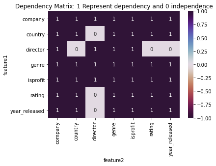

```python
fig = sns.heatmap(dependency_matrix.astype(int), vmin=-1, vmax=1, cmap='twilight_shifted_r', annot=True);
fig.set_title('Dependency Matrix: 1 Represent dependency and 0 independence');
```

# 3. Frequent Pattern Analysis

Our data has the following columns that we can perform frequent pattern analysis on:

- Genres_edited
- Spoken_languages_edited
- Keywords_edited
- Overview

> We want to find out whether there are recurring relationships in the data. For example, which genres are frequently used together to produce movies? Or which keyword combinations are frequent? After performing the analyses, we can decide, for example, which genres to produce in order to make the most profit.  
> After writing some general functions, we will perform the analyses one by one.

## 3.1. Genres

```python
df.genres_edited.value_counts()
```

```
Drama                                        251
Comedy                                       242
Comedy, Drama                                133
Drama, Romance                               124
Comedy, Romance                              110
                                            ...
Thriller, Action, Comedy, Science Fiction      1
Science Fiction, Drama                         1
Adventure, War, History                        1
Fantasy, Adventure, Animation, Family          1
Family, Adventure, Science Fiction             1
Name: genres_edited, Length: 907, dtype: int64
```

```python
df['genres_list'] = df.genres_edited.str.split(', ')
df['genres_list'] = df.genres_list.apply(lambda x: np.array(sorted(x)))
```

```python
te = TransactionEncoder()
te_ary = te.fit(np.array(df.genres_list)).transform(np.array(df.genres_list))
```

```python
genres_encoded = pd.DataFrame(te_ary,columns=te.columns_)
genres_encoded.head()
```

|  | 0 | Action | Adventure | Animation | Comedy | Crime | Documentary | Drama | Family | Fantasy | ... | History | Horror | Music | Mystery | Romance | Science Fiction | TV Movie | Thriller | War | Western |
| --- | --- | --- | --- | --- | --- | --- | --- | --- | --- | --- | --- | --- | --- | --- | --- | --- | --- | --- | --- | --- | --- |
| 0 | False | False | False | False | False | True | False | True | False | False | ... | False | False | False | False | False | False | False | False | False | False |
| 1 | False | False | False | False | True | False | False | False | False | False | ... | False | False | False | False | False | False | False | False | False | False |
| 2 | False | True | False | False | False | False | False | False | False | False | ... | False | False | False | False | True | False | False | False | True | False |
| 3 | False | True | False | False | False | False | False | False | False | False | ... | False | True | False | False | False | True | False | True | False | False |
| 4 | False | False | True | False | False | False | False | False | True | False | ... | False | False | False | False | False | True | False | False | False | False |

5 rows × 21 columns

```python
frequent_itemsets_genres = apriori(genres_encoded, min_support=0.05, use_colnames=True)\
                           .sort_values('support',ascending=False)
frequent_itemsets_genres['length'] = frequent_itemsets_genres.itemsets.apply(lambda x: len(x))
```

```python
frequent_itemsets_genres[(frequent_itemsets_genres.length==2)&
                         (frequent_itemsets_genres.support>=0.1)]
```

|  | support | itemsets | length |
| --- | --- | --- | --- |
| 19 | 0.140182 | (Comedy, Drama) | 2 |
| 24 | 0.125709 | (Romance, Drama) | 2 |
| 17 | 0.119467 | (Action, Thriller) | 2 |
| 25 | 0.117764 | (Thriller, Drama) | 2 |
| 21 | 0.112089 | (Romance, Comedy) | 2 |

```python
frequent_itemsets_genres[(frequent_itemsets_genres.length==3)&
                         (frequent_itemsets_genres.support>=0.05)]
```

|  | support | itemsets | length |
| --- | --- | --- | --- |
| 28 | 0.058173 | (Romance, Comedy, Drama) | 3 |
| 29 | 0.053632 | (Thriller, Drama, Crime) | 3 |

```python
rules = association_rules(frequent_itemsets_genres, metric='confidence', min_threshold=0.0)
rules.sort_values('confidence',ascending=False).head()
```

|  | antecedents | consequents | antecedent support | consequent support | support | confidence | lift | leverage | conviction |
| --- | --- | --- | --- | --- | --- | --- | --- | --- | --- |
| 16 | (Family) | (Comedy) | 0.113507 | 0.419977 | 0.078320 | 0.690000 | 1.642946 | 0.030650 | 1.871041 |
| 2 | (Romance) | (Drama) | 0.185868 | 0.471623 | 0.125709 | 0.676336 | 1.434060 | 0.038050 | 1.632485 |
| 36 | (Mystery) | (Thriller) | 0.080590 | 0.274972 | 0.054484 | 0.676056 | 2.458640 | 0.032324 | 2.238131 |
| 40 | (Crime, Drama) | (Thriller) | 0.088820 | 0.274972 | 0.053632 | 0.603834 | 2.195986 | 0.029209 | 1.830112 |
| 8 | (Romance) | (Comedy) | 0.185868 | 0.419977 | 0.112089 | 0.603053 | 1.435919 | 0.034028 | 1.461211 |

```python
rules['antecedents_len'] = rules.antecedents.apply(lambda x: len(x))
```

```python
rules[
    (rules.antecedents_len >= 2) &
    (rules.confidence      >= .3) &
    (rules.lift            >= 1) &
    (rules.leverage        >= 0.01) &
    (rules.conviction      >= 1)
]
```

|  | antecedents | consequents | antecedent support | consequent support | support | confidence | lift | leverage | conviction | antecedents_len |
| --- | --- | --- | --- | --- | --- | --- | --- | --- | --- | --- |
| 30 | (Comedy, Drama) | (Romance) | 0.140182 | 0.185868 | 0.058173 | 0.414980 | 2.232654 | 0.032117 | 1.391630 | 2 |
| 38 | (Thriller, Drama) | (Crime) | 0.117764 | 0.165437 | 0.053632 | 0.455422 | 2.752841 | 0.034150 | 1.532494 | 2 |
| 40 | (Crime, Drama) | (Thriller) | 0.088820 | 0.274972 | 0.053632 | 0.603834 | 2.195986 | 0.029209 | 1.830112 | 2 |

## 3.2. Spoken Languages

```python
df.spoken_languages_edited.value_counts()
```

```
en                                    2523
en, es                                 120
en, fr                                  87
en, de                                  43
en, it                                  41
                                      ...
en, el, es                               1
en, fr, hi, it, la, zh, pt, ru, bo       1
en, ja, ru, es                           1
he, la                                   1
cn, en, fr, zh                           1
Name: spoken_languages_edited, Length: 353, dtype: int64
```

```python
def trysort(x):
    try: return sorted(x)
    except: return []
```

```python
df['spoken_languages_list'] = df.spoken_languages_edited.str.split(', ')
df['spoken_languages_list'] = df.spoken_languages_list.apply(trysort)
```

```python
te = TransactionEncoder()
te_ary = te.fit(np.array(df.spoken_languages_list)).transform(np.array(df.spoken_languages_list))
```

```python
spoken_languages_encoded = pd.DataFrame(te_ary,columns=te.columns_)
spoken_languages_encoded.head()
```

|  | 0 | af | ar | bg | bn | bo | br | bs | cn | cs | ... | tl | to | tr | uk | ur | vi | xh | yi | zh | zu |
| --- | --- | --- | --- | --- | --- | --- | --- | --- | --- | --- | --- | --- | --- | --- | --- | --- | --- | --- | --- | --- | --- |
| 0 | False | False | False | False | False | False | False | False | False | False | ... | False | False | False | False | False | False | False | False | False | False |
| 1 | False | False | False | False | False | False | False | False | False | False | ... | False | False | False | False | False | False | False | False | False | False |
| 2 | False | False | False | False | False | False | False | False | False | False | ... | False | False | False | False | False | False | False | False | False | False |
| 3 | False | False | False | False | False | False | False | False | False | False | ... | False | False | False | False | False | False | False | False | False | False |
| 4 | False | False | False | False | False | False | False | False | False | False | ... | False | False | False | False | False | False | False | False | False | False |

5 rows × 71 columns

```python
frequent_itemsets_spoken_languages = apriori(spoken_languages_encoded, min_support=0.05, use_colnames=True)\
                           .sort_values('support',ascending=False)
frequent_itemsets_spoken_languages['length'] = frequent_itemsets_spoken_languages.itemsets.apply(lambda x: len(x))
```

```python
frequent_itemsets_spoken_languages[
                         (frequent_itemsets_spoken_languages.support>=0.05)]
```

|  | support | itemsets | length |
| --- | --- | --- | --- |
| 0 | 0.989217 | (en) | 1 |
| 2 | 0.077185 | (fr) | 1 |
| 1 | 0.076617 | (es) | 1 |
| 3 | 0.075482 | (en, es) | 2 |
| 4 | 0.075482 | (en, fr) | 2 |

```python
frequent_itemsets_spoken_languages[(frequent_itemsets_spoken_languages.length==3)&
                         (frequent_itemsets_spoken_languages.support>=0.05)]
```

|  | support | itemsets | length |
| --- | --- | --- | --- |

```python
rules = association_rules(frequent_itemsets_spoken_languages, metric='confidence', min_threshold=0.05)
rules.sort_values('confidence',ascending=False)
```

|  | antecedents | consequents | antecedent support | consequent support | support | confidence | lift | leverage | conviction |
| --- | --- | --- | --- | --- | --- | --- | --- | --- | --- |
| 1 | (es) | (en) | 0.076617 | 0.989217 | 0.075482 | 0.985185 | 0.995924 | -0.000309 | 0.727866 |
| 3 | (fr) | (en) | 0.077185 | 0.989217 | 0.075482 | 0.977941 | 0.988601 | -0.000870 | 0.488838 |
| 0 | (en) | (es) | 0.989217 | 0.076617 | 0.075482 | 0.076305 | 0.995924 | -0.000309 | 0.999662 |
| 2 | (en) | (fr) | 0.989217 | 0.077185 | 0.075482 | 0.076305 | 0.988601 | -0.000870 | 0.999048 |

```python
rules['antecedents_len'] = rules.antecedents.apply(lambda x: len(x))
```

```python
rules[
    (rules.antecedents_len >= 1) &
    (rules.confidence      >= .3) &
    (rules.lift            >= 0.75) &
    (rules.conviction      >= 0.5)
]
```

|  | antecedents | consequents | antecedent support | consequent support | support | confidence | lift | leverage | conviction | antecedents_len |
| --- | --- | --- | --- | --- | --- | --- | --- | --- | --- | --- |
| 1 | (es) | (en) | 0.076617 | 0.989217 | 0.075482 | 0.985185 | 0.995924 | -0.000309 | 0.727866 | 1 |

## 3.3. Keywords

```python
df.keywords_edited.value_counts()
```

```
independent film                                                                                                                                             21
woman director                                                                                                                                               11
sport                                                                                                                                                         9
0                                                                                                                                                             9
duringcreditsstinger                                                                                                                                          8
                                                                                                                                                             ..
killing, undercover, secret agent, british secret service                                                                                                     1
psychiatric hospital, heroin addict, electroconvulsive therapy, death of daughter, bebop, jazz music, eiffel tower paris                                      1
recruit, puppet, killer doll, serial killer, military academy, killer toys, toy comes to life, war games                                                      1
prophecy, falsely accused, baby, monster, hero, queen, traitor, magic, fantasy, castle, sorcerer's apprentice, black magic, aggression by animal, mission     1
new zealand, utah, life's dream, motor sport, independent film, motorcycle, trailer, mortgage                                                                 1
Name: keywords_edited, Length: 3280, dtype: int64
```

```python
def trysort(x):
    try: return sorted(x)
    except: return []
```

```python
df['keywords_list'] = df.keywords_edited.str.split(', ')
df['keywords_list'] = df.keywords_list.apply(trysort)
```

```python
te = TransactionEncoder()
te_ary = te.fit(np.array(df.keywords_list)).transform(np.array(df.keywords_list))
```

```python
keywords_encoded = pd.DataFrame(te_ary,columns=te.columns_)
keywords_encoded.head()
```

|  | 0 | 15th century | 16th century | 17th century | 18th century | 1910s | 1920s | 1930s | 1940s | 1950s | ... |  | armwrestling | epileptic seizure | flipping coin | north carolinam | nosferatu | Øverste hylde | 卧底肥妈 | 绝地奶霸 | 超级妈妈 |
| --- | --- | --- | --- | --- | --- | --- | --- | --- | --- | --- | --- | --- | --- | --- | --- | --- | --- | --- | --- | --- | --- |
| 0 | False | False | False | False | False | False | False | False | False | True | ... | False | False | False | True | False | False | False | False | False | False |
| 1 | False | False | False | False | False | False | False | False | False | False | ... | False | False | False | False | False | False | False | False | False | False |
| 2 | False | False | False | False | False | False | False | False | False | False | ... | False | False | False | False | False | False | False | False | False | False |
| 3 | False | False | False | False | False | False | False | False | False | False | ... | False | False | False | False | False | False | False | False | False | False |
| 4 | False | False | False | False | False | False | False | False | False | False | ... | False | False | False | False | False | False | False | False | False | False |

5 rows × 8369 columns

```python
frequent_itemsets_keywords = apriori(keywords_encoded, min_support=0.05, use_colnames=True)\
                           .sort_values('support',ascending=False)
frequent_itemsets_keywords['length'] = frequent_itemsets_keywords.itemsets.apply(lambda x: len(x))
```

```python
frequent_itemsets_keywords[
                         (frequent_itemsets_keywords.support>=0.05)]
```

|  | support | itemsets | length |
| --- | --- | --- | --- |
| 0 | 0.068104 | (duringcreditsstinger) | 1 |
| 1 | 0.063564 | (independent film) | 1 |
| 2 | 0.061010 | (woman director) | 1 |

```python
rules = association_rules(frequent_itemsets_keywords, metric='confidence', min_threshold=0.05)
rules.sort_values('confidence',ascending=False)
```

|  | antecedents | consequents | antecedent support | consequent support | support | confidence | lift | leverage | conviction |
| --- | --- | --- | --- | --- | --- | --- | --- | --- | --- |

```python
rules['antecedents_len'] = rules.antecedents.apply(lambda x: len(x))
```

```python
rules[
    (rules.antecedents_len >= 1) &
    (rules.confidence      >= .3) &
    (rules.lift            >= 0.75) &
    # (rules.leverage        >= 0.01) &
    (rules.conviction      >= 0.5)
]
```

|  | antecedents | consequents | antecedent support | consequent support | support | confidence | lift | leverage | conviction | antecedents_len |
| --- | --- | --- | --- | --- | --- | --- | --- | --- | --- | --- |

## 3.4. Overview

```python
df.overview.value_counts()
```

```
0                                                                                                                                                                                                                                                                                                           …
William Hundert is a passionate and principled Classics professor who finds his tightly-controlled world shaken and inexorably altered when a new student, Sedgewick Bell, walks into his classroom. What begins as a fierce battle of wills gives way to a close student-teacher relationship, but results …
A young man is in a race against time as he searches for a cure after becoming infected with a virus that will eventually turn him into a blood-sucking vampire.                                                                                                                                            …
Everybody's favorite stiff is back! Working fools Larry Wilson and Richard Parker have uncovered a dirty, little secret: Their former boss, Bernie Lomax, embezzled $2 million and placed it in a safe deposit box in the Caribbean. Now, the boys are ready to go after the loot, but they can't do it alon…
Two women, one (Cameron Diaz) from America and one (Kate Winslet) from Britain, swap homes at Christmastime after bad breakups with their boyfriends. Each woman finds romance with a local man (Jude Law, Jack Black) but realizes that the imminent return home may end the relationship.                 …
                                                                                                                                                                                                                                                                                                            …
A store clerk and an ice cream truck driver are thrown together when a dying scientist entrusts them with a deadly chemical kept in ice. This chemical will kill every living thing once it melts. They have to take the chemical codenamed 'Elvis' to the next nearest military base while being chased by …
A car magnate watches his personal and professional life hit the skids because of his business and romantic indiscretions.                                                                                                                                                                                  …
Immortals Connor and Duncan Macleod join forces against a man from Connor's distant past in the highlands of Scotland, Kell, an immensely powerful immortal who leads an army of equally powerful and deadly immortal swordsmen and assassins. No immortal alive has been able to defeat Kell yet, and neith…
Amiable slackers Bill and Ted are once again roped into a fantastical adventure when De Nomolos, a villain from the future, sends evil robot duplicates of the two lads to terminate and replace them. The robot doubles actually succeed in killing Bill and Ted, but the two are determined to escape the …
A university student and some classmates are recruited to carry out a private experiment -- to create a poltergeist. Their subject: an alluring, but dangerously disturbed young woman. Their quest: to explore the dark energy that her damaged psyche might manifest. As the experiment unravels along wit…
Name: overview, Length: 3515, dtype: int64
```

```python
def trysort(x):
    try: return sorted(x)
    except: return []
```

```python
df['overview_list'] = df.overview.str.split(' ')
df['overview_list'] = df.overview_list.apply(trysort)
```

```python
te = TransactionEncoder()
te_ary = te.fit(np.array(df.overview_list)).transform(np.array(df.overview_list))
```

```python
overview_encoded = pd.DataFrame(te_ary,columns=te.columns_)
overview_encoded.head()
```

|  |  | "300" | "300," | "300: | "88 | "A | "A.J." | "Address | "American | "Anthony | ... | “Tributes” | “Walk | “adorable” | “an | “friend” | “heroes” | “playbook,” | “runners” | “stalkers” | … |
| --- | --- | --- | --- | --- | --- | --- | --- | --- | --- | --- | --- | --- | --- | --- | --- | --- | --- | --- | --- | --- | --- |
| 0 | False | False | False | False | False | False | False | False | False | False | ... | False | False | False | False | False | False | False | False | False | False |
| 1 | False | False | False | False | False | False | False | False | False | False | ... | False | False | False | False | False | False | False | False | False | False |
| 2 | True | False | False | False | False | False | False | False | False | False | ... | False | False | False | False | False | False | False | False | False | False |
| 3 | False | False | False | False | False | False | False | False | False | False | ... | False | False | False | False | False | False | False | False | False | False |
| 4 | False | False | False | False | False | False | False | False | False | False | ... | False | False | False | False | False | False | False | False | False | False |

5 rows × 29322 columns

```python
frequent_itemsets_overview = apriori(overview_encoded, min_support=0.05, use_colnames=True)\
                           .sort_values('support',ascending=False)
frequent_itemsets_overview['length'] = frequent_itemsets_overview.itemsets.apply(lambda x: len(x))
```

```python
frequent_itemsets_overview[
                         (frequent_itemsets_overview.support>=0.05)]
```

|  | support | itemsets | length |
| --- | --- | --- | --- |
| 54 | 0.842509 | (the) | 1 |
| 8 | 0.831158 | (a) | 1 |
| 59 | 0.755108 | (to) | 1 |
| 13 | 0.722758 | (and) | 1 |
| 164 | 0.701476 | (the, a) | 2 |
| ... | ... | ... | ... |
| 4735 | 0.050227 | (and, he, the, for, in) | 5 |
| 657 | 0.050227 | (with, a, When) | 3 |
| 5563 | 0.050227 | (the, for, a, in, to, that) | 6 |
| 4593 | 0.050227 | (of, the, a, on, who) | 5 |
| 2719 | 0.050227 | (only, the, to, a) | 4 |

5996 rows × 3 columns

```python
rules = association_rules(frequent_itemsets_overview, metric='confidence', min_threshold=0.05)
rules.sort_values('confidence',ascending=False)
```

|  | antecedents | consequents | antecedent support | consequent support | support | confidence | lift | leverage | conviction |
| --- | --- | --- | --- | --- | --- | --- | --- | --- | --- |
| 97572 | (when, to, of, in) | (the) | 0.057321 | 0.842509 | 0.056754 | 0.990099 | 1.175180 | 0.008460 | 15.906640 |
| 124355 | (when, of, a, in, to) | (the) | 0.052497 | 0.842509 | 0.051930 | 0.989189 | 1.174100 | 0.007700 | 14.567963 |
| 78451 | (be, of, and) | (the) | 0.062145 | 0.842509 | 0.061294 | 0.986301 | 1.170672 | 0.008936 | 11.496879 |
| 90842 | (be, of, to, and) | (the) | 0.059024 | 0.842509 | 0.058173 | 0.985577 | 1.169812 | 0.008444 | 10.919410 |
| 97603 | (of, and, in, to, are) | (the) | 0.057605 | 0.842509 | 0.056754 | 0.985222 | 1.169391 | 0.008221 | 10.656924 |
| ... | ... | ... | ... | ... | ... | ... | ... | ... | ... |
| 136726 | (the) | (for, who, in) | 0.842509 | 0.053916 | 0.050227 | 0.059616 | 1.105721 | 0.004802 | 1.006061 |
| 138469 | (the) | (this, and) | 0.842509 | 0.054767 | 0.050227 | 0.059616 | 1.088533 | 0.004085 | 1.005156 |
| 136756 | (the) | (has, is, and, in) | 0.842509 | 0.054200 | 0.050227 | 0.059616 | 1.099931 | 0.004563 | 1.005760 |
| 136877 | (the) | (and, in, life) | 0.842509 | 0.053916 | 0.050227 | 0.059616 | 1.105721 | 0.004802 | 1.006061 |
| 138707 | (the) | (for, and, he, in) | 0.842509 | 0.051930 | 0.050227 | 0.059616 | 1.148016 | 0.006476 | 1.008174 |

138822 rows × 9 columns

```python
rules['antecedents_len'] = rules.antecedents.apply(lambda x: len(x))
```

```python
rules[
    (rules.antecedents_len >= 1) &
    (rules.confidence      >= .3) &
    (rules.lift            >= 0.75) &
    (rules.conviction      >= 0.5)
]
```

|  | antecedents | consequents | antecedent support | consequent support | support | confidence | lift | leverage | conviction | antecedents_len |
| --- | --- | --- | --- | --- | --- | --- | --- | --- | --- | --- |
| 0 | (the) | (a) | 0.842509 | 0.831158 | 0.701476 | 0.832604 | 1.001739 | 0.001218 | 1.008637 | 1 |
| 1 | (a) | (the) | 0.831158 | 0.842509 | 0.701476 | 0.843974 | 1.001739 | 0.001218 | 1.009393 | 1 |
| 2 | (the) | (to) | 0.842509 | 0.755108 | 0.655505 | 0.778040 | 1.030369 | 0.019320 | 1.103315 | 1 |
| 3 | (to) | (the) | 0.755108 | 0.842509 | 0.655505 | 0.868095 | 1.030369 | 0.019320 | 1.193974 | 1 |
| 4 | (to) | (a) | 0.755108 | 0.831158 | 0.645573 | 0.854942 | 1.028615 | 0.017959 | 1.163962 | 1 |
| ... | ... | ... | ... | ... | ... | ... | ... | ... | ... | ... |
| 138810 | (only, to, a) | (the) | 0.054200 | 0.842509 | 0.050227 | 0.926702 | 1.099931 | 0.004563 | 2.148634 | 3 |
| 138812 | (only, the) | (to, a) | 0.062997 | 0.645573 | 0.050227 | 0.797297 | 1.235022 | 0.009558 | 1.748505 | 2 |
| 138813 | (only, to) | (the, a) | 0.061294 | 0.701476 | 0.050227 | 0.819444 | 1.168172 | 0.007231 | 1.653366 | 2 |
| 138814 | (only, a) | (the, to) | 0.060159 | 0.655505 | 0.050227 | 0.834906 | 1.273683 | 0.010793 | 2.086655 | 2 |
| 138818 | (only) | (the, to, a) | 0.068104 | 0.560159 | 0.050227 | 0.737500 | 1.316591 | 0.012078 | 1.675585 | 1 |

72283 rows × 10 columns

# 4. Results

## 4.1. Data Exploration Results - Continuous Features

As we analyze three continuous features in Section 2.1., namely *budget*, *gross (revenue)*, and *profitability_ratio*, the data seems clean enough to build our model on. Even though all the three features are positively skewed, we do not observe so many outliers that will disturb training the model.

Our initial hypothesis was that our three continuous features were meant to be correlated, because intiutively, the budget and gross and profitability of a movie sound correlated. That is, however, not the case, at least for profitability ratio and the others.

Nonetheless, we can conclude that budget and gross are correlated. Although this information does not help us predicting the profitability ratio, we understand how independent the profitability ratio is and take it into account when we build our Machine Learning models.

## 4.2. Data Exploration Results - Categorical Features

After analyzing our categorical features in Section 2.2., we see somewhat imbalance in our 6 features. Although we have to take the imbalance problem while modeling, the one feature, *isprofit*, turns out to be very balanced. Since the *isprofit* feature is our **target feature**, we will choose a metric that objectively evaluates model performance in our classification problem.

After calculating the imbalances, we performed chi-square tests for each pair possible out of our 7 categorical features. In results of chi-square test (shared in Section 2.2.2.2.), we observe there are quite enough couple of features that are dependent and independent. For example, *company* and *country* are correlated as we initially expected, because most of the movies in our data is made in the US.

## 4.2. Frequent Pattern Analysis Results

Our data included a set of features that we could perform frequent pattern analysis on, which we used for building association rules in Section 3.

Since our dataset is not a kind of transactional data, these rules are not meant to be used for modeling. However, we still wanted to conduct this analysis in order to turn the learnings from our lectures into practice.

When we think about those rules, they actually makes sense! For example, most of the family movies have comedy inside as well.